# Pendeln in Deutschland

Zeit für die Bahn? – Eine datenbasierte Analyse

# Motivation

Jeden Morgen das gleiche Bild: Verstopfte Autobahnen, genervte Pendler, verlorene Zeit. **20,5 Millionen Menschen** pendeln in Deutschland täglich zur Arbeit – die meisten davon mit dem Auto. Laut [INRIX Traffic Scorecard 2024](https://inrix.com/scorecard/) verlieren Pendler in deutschen Großstädten zwischen 40 und 60 Stunden pro Jahr allein im Stau. Das entspricht fast einer kompletten Arbeitswoche, die im Nichts verpufft.

Die Idee liegt auf der Hand: **Wer Bahn fährt, steht nicht im Stau.** Aber wie schlägt sich die Bahn im Vergleich zum Auto? Ist sie wirklich schneller? Und wie zuverlässig ist sie eigentlich?

In diesem Projekt analysieren Sie **Echtzeitdaten der Deutschen Bahn**, **Pendlerstatistiken der Bundesagentur für Arbeit**, **Staudaten von INRIX** und die **Entgeltstatistik der Bundesagentur für Arbeit**. Sie werden herausfinden, dass die Antwort auf die Frage “Sollten mehr Menschen Bahn fahren?” komplexer ist, als man zunächst vermuten würde und dass sie wichtige Implikationen für die Verkehrspolitik hat.

Ihre zentrale Forschungsfrage lautet:

> **“Sollten mehr Menschen Bahn fahren – und was müsste sich dafür ändern?”**

# Datengrundlage

In diesem Projekt arbeiten Sie mit mehreren Datensätzen. Ein wichtiger Teil des Projekts ist das **eigenständige Beschaffen von Primärdaten** aus offiziellen Quellen.

## Daten einlesen und verstehen

Bevor Sie mit der Analyse beginnen können, müssen Sie verschiedenste Datensätze einlesen und deren Struktur verstehen. Die Deutsche Bahn stellt über unterschiedliche Schnittstellen Echtzeitdaten für ihre Züge als open-source Daten zur Verfügung, welche per API-Calls geladen werden können. Jedoch gibt es von der Deutschen Bahn keine offizielle Seite, welche historische Daten zu Zugverspätungen, Ausfällen etc. für Fern- und Nahverkehrszüge sammelt. Da wir uns jedoch mit historischen Daten beschäftigen möchten, greifen wir auf Daten zurück, die von [Piet Brömmel](https://github.com/piebro/deutsche-bahn-data) gesammelt wurden und bei Huggingface im **Parquet-Format** zur Verfügung gestellt wurden. Das **Parquet-Format** ist ein effizientes Datenformat und wird oft für große Datenmengen genutzt; in R können Sie diese Daten mit dem `arrow`-Paket einlesen.

1. **Wie pünktlich ist die Bahn wirklich?** Um diese Frage zu beantworten, brauchen Sie echte Verspätungsdaten – nicht nur Pressemitteilungen. Die Bahndaten bilden das **Herzstück unserer Analyse**: Mit ihnen können Sie berechnen, wie viel Zeit Bahnfahrer durch Verspätungen verlieren und später mit den Stauzeiten der Autofahrer vergleichen.

Die Deutsche Bahn stellt Echtzeitdaten als Open Data zur Verfügung. Das Projekt piebro/deutsche-bahn-data auf Huggingface sammelt diese Daten im Parquet-Format.

Laden Sie die Datei für **November 2025** direkt von Huggingface herunter und lesen Sie diesen Datensatz als `bahn` in R ein.

Zeigen Sie die ersten 10 Zeilen des Datensatzes in einer Tabelle und beantworten Sie anschließend folgende Fragen:

- Wie viele Beobachtungen enthält der Datensatz? Welche Variablen sind vorhanden?
- Was stellt eine einzelne Beobachtung dar?

*Hinweis 1:* Sie können auf Huggingface die gesuchte Datei [hier](https://huggingface.co/datasets/piebro/deutsche-bahn-data/resolve/main/monthly_processed_data/data-2025-11.parquet) finden und direkt die URL zu der Datei in R mitgeben

*Hinweis 2:* Sie können die Parquet Datei entweder lokal speichern, oder immer direkt per URL einlesen. Falls Sie die Datei lokal speichern, so wird diese nicht auf GitHub Committet, da wir dies in der .gitignore entsprechend eingestellt haben. In diesem Fall sollten alle Teammitglieder die Datei lokal zur Verfügung haben.

*Hinweis 3:* Achten Sie bei allen Tabellen auf einer saubere Darstellung

Erste 10 Beobachtungen der Bahndaten

Daten für November 2025

| Bahnhof | xml_station_name | eva | Zugname | Zielbahnhof | Verspätung (Minuten) | Zeitpunkt | Ausgefallen | Zugtyp | Zugfahrt ID | Stationnummer | geplante Ankunftszeit | geänderte Ankunftszeit | geplante Abfahrtszeit | geänderte Abfahrtszeit | id |
| --- | --- | --- | --- | --- | --- | --- | --- | --- | --- | --- | --- | --- | --- | --- | --- |
| Stuttgart Hbf | Stuttgart Hbf (tief) | 08098096 | S 2 | Filderstadt | 5 | 2025-11-01 01:00:00 | FALSE | S |  | 15 | 2025-11-01 00:55:00 | 2025-11-01 00:57:00 | 2025-11-01 00:55:00 | 2025-11-01 01:00:00 | -1263112065111090114-2510312318-15 |
| Halle (Saale) Hbf | Halle(Saale)Hbf | 08010159 | S 5 | Leipzig Hbf (tief) | 1 | 2025-11-01 01:00:00 | FALSE | S |  | 1 | NA | NA | 2025-11-01 00:59:00 | 2025-11-01 01:00:00 | -2678885466088426112-2510312359-1 |
| Karlsruhe Hbf | Karlsruhe Hbf | 08000191 | RE 1 | Karlsruhe Hbf | 95 | 2025-11-01 01:00:00 | FALSE | RE |  | 7 | 2025-10-31 23:25:00 | 2025-11-01 01:00:00 | NA | NA | -2791458000270945298-2510312132-7 |
| Regensburg Hbf | Regensburg Hbf | 08000309 | ALX RE25 | München Hbf | 11 | 2025-11-01 01:00:00 | FALSE | ALX |  | 4 | 2025-11-01 00:35:00 | 2025-11-01 00:52:00 | 2025-11-01 00:49:00 | 2025-11-01 01:00:00 | -5065801516765768983-2510312301-4 |
| Mannheim Hbf | Mannheim Hbf | 08000244 | ICE 775 | Karlsruhe Hbf | 1 | 2025-11-01 01:00:00 | FALSE | ICE | 5181720942697741094 | 8 | 2025-11-01 00:56:00 | 2025-11-01 00:58:00 | 2025-11-01 00:59:00 | 2025-11-01 01:00:00 | 5181720942697741094-2510311916-8 |
| Flughafen BER | Flughafen BER (S-Bahn) | 08089201 | S 9 | Flughafen BER | 1 | 2025-11-01 01:00:00 | FALSE | S | 7409107008547428277 | 5 | 2025-11-01 00:59:00 | 2025-11-01 01:00:00 | NA | NA | 7409107008547428277-2510312346-5 |
| Halle (Saale) Hbf | Halle(Saale)Hbf | 08010159 | S 8 | Halle (Saale) Hbf | 15 | 2025-11-01 01:00:00 | FALSE | S | 2442677234119162947 | 6 | 2025-11-01 00:45:00 | 2025-11-01 01:00:00 | NA | NA | 2442677234119162947-2510312324-6 |
| München Hbf | München Hbf | 08000261 | RB 40 | München Hbf | 0 | 2025-11-01 01:00:00 | FALSE | RB |  | 8 | 2025-11-01 01:00:00 | 2025-11-01 01:00:00 | NA | NA | -8549369502950901321-2510312246-8 |
| Köln Hbf | Köln Hbf | 08000207 | IC 1952 | Köln Hbf | 40 | 2025-11-01 01:00:00 | FALSE | IC | 2365115903117509345 | 14 | 2025-11-01 00:20:00 | 2025-11-01 01:00:00 | NA | NA | 2365115903117509345-2510311747-14 |
| Freiburg (Breisgau) Hbf | Freiburg(Breisgau) Hbf | 08000107 | S 1 | Freiburg (Breisgau) Hbf | 0 | 2025-11-01 01:00:00 | FALSE | S |  | 9 | 2025-11-01 01:00:00 | 2025-11-01 01:00:00 | NA | NA | -2150665481183031960-2510312332-9 |

### Anzahl der Beobachtungen

Der Datensatz für November 2025 enthält 13.943.561, also etwa 14 Millionen Beobachtungen.

### Variablen im Datensatz `bahn`

Es sind in dem Datensatz Informationen zu Bahnhöfen, Zügen und deren zeitlichem Ablauf enthalten. Die Variablen lassen sich in Stationsinformationen (wie `station_name`, also dem Bahnhofsname oder der Bahnhofs-ID `eva`), Zug- und Linienmerkmale (z.B. `train_name` und `final_destination_station`), zeitliche Angaben zu geplanten und tatsächlichen Ankunfts- bzw. Abfahrtszeiten (etwa `arrival_planned_time` und `arrival_change_time` für die Ankunftszeiten) sowie Zuverlässigkeitsindikatoren wie Verspätungen und Ausfälle (`delay_in_min` und `is_canceled`) einteilen. Dadurch erlaubt der Datensatz eine detaillierte Analyse der Pünktlichkeit und Zuverlässigkeit des Bahnverkehrs.

### Beobachtungen im Datensatz

Eine Beobachtung ist ein einzelnes Zugereignis innerhalb einer Fahrt, nämlich der Halt eines bestimmten Zuges an einem bestimmten Bahnhof, einschließlich geplanter und tatsächlicher Ankunfts- und Abfahrtszeiten sowie der daraus resultierenden Verspätung oder eines Ausfalls. Es kommt vor, dass ein und derselbe Zug mehrfach in der Tabelle vorkommen, weil Fahrtdaten, wie Verspätung und Ankunftszeit zwischen Station A und B anders sein werden, als zwischen B und C. Dabei handelt es sich dann um verschiedene Beobachtungen. Eine Beobachtung wird eindeutig durch die Spalte “id” identifiziert.

2. **Wohin pendeln die Menschen?** Die Bahndaten zeigen ihnen die Pünktlichkeit der Züge – aber um zu verstehen, wo gute Bahnverbindungen besonders wichtig sind, müssen Sie wissen, **wohin die Menschen pendeln**. Die Pendlerstatistik der Bundesagentur für Arbeit zeigt genau das: Welche Städte sind die größten Arbeitgeber-Magneten?

Laden Sie den Datensatz `pendler_kreise_aufbereitet.csv` aus dem Ordner `daten` in R ein als Datensatz `pendler`.

Erstellen Sie eine Tabelle der **Top 10 Städte** nach Einpendlern mit den Spalten: Stadt (kreis_name), Einpendler, Auspendler, Pendlersaldo.

Interpretieren Sie kurz: Welche Städte sind die größten “Pendlermagneten” Deutschlands und warum?

Top 10 Städte nach Einpendlern

Pendlerdaten pro Kreis

| Stadt | Einpendler | Auspendler | Pendlersaldo |
| --- | --- | --- | --- |
| München, Landeshauptstadt | 455.645 | 202.756 | 252.889 |
| Frankfurt am Main, Stadt | 405.856 | 111.245 | 294.611 |
| Hamburg, Freie und Hansestadt | 392.951 | 147.328 | 245.623 |
| Berlin, Stadt | 392.324 | 219.898 | 172.426 |
| Köln, Stadt | 306.905 | 138.422 | 168.483 |
| Düsseldorf, Stadt | 284.696 | 97.326 | 187.370 |
| Stuttgart, Landeshauptstadt | 274.442 | 100.095 | 174.347 |
| Nürnberg, Stadt | 165.496 | 78.557 | 86.939 |
| Essen, Stadt | 141.296 | 90.906 | 50.390 |
| Region Hannover | 137.924 | 69.974 | 67.950 |

### Interpretation der Tabelle und Bedeutung der Daten

Die Tabelle ‘Top 10 Städte nach Einpendlern’, zeigt deren Einpendler-, Auspendler- und Pendlersaldo-Zahlen. Sie macht deutlich, dass vor allem große Metropolen und Wirtschaftsstandorte die meisten Einpendler anziehen. Die größten Pendlermagneten sind München (ca. 455,6 Tsd.), Frankfurt am Main (ca. 405,9 Tsd.), Hamburg (ca. 393 Tsd.) und Berlin (ca. 392,3 Tsd.). Metropolen sind mit einer hohen Konzentration an Arbeitsplätzen besonders starke Pendlermagneten. Mitunter spielen vermutlich die Wohnungsknappheit, wie auch steigende Mietpreise eine Rolle, warum viele Menschen in diese Großstädte pendeln, um zu ihren Arbeitsplätzen zu gelangen.

3. **Was kostet das Auto?** Sie haben jetzt Bahndaten und wissen, wohin die Menschen pendeln. Aber um fair vergleichen zu können, brauchen Sie auch die **Alternative**: Wie viel Zeit verlieren Autofahrer im Stau? Diese Daten liefert INRIX – ein Unternehmen, das weltweit Verkehrsdaten sammelt. Später werden Sie diese Staukosten mit den Bahnverspätungen vergleichen.

Besuchen Sie die [INRIX Global Traffic Scorecard](https://inrix.com/scorecard/) und suchen Sie die Stauzeiten für die Top 10 Städte aus Aufgabe 2 und zusätzlich die Stauzeiten für Ulm. INRIX misst, wie viele Stunden Autofahrer jährlich im Stau verlieren.

- Erstellen Sie eine eigene CSV-Datei `inrix_staedte_2024.csv` mit folgenden Spalten für die geforderten Städte:
  - `stadt`: Name der Stadt
  - `stau_stunden_jahr`: Jährliche Staustunden pro Fahrer
  - `kosten_eur`: Jährliche Kosten pro Fahrer (findet sich in der tiefergehenden Übersicht)
- Berechnen Sie für jede Stadt, wie viele **Arbeitstage pro Jahr** im Stau verloren gehen. Annahme: Ein Arbeitstag = 8 Stunden.

Erstellen Sie anschließend eine schöne Tabelle mit: Stadt, Staustunden/Jahr, verlorene Arbeitstage und beschreiben diese. In welcher Stadt ist die Stausituation am schlimmsten? Wie viele Arbeitstage verliert ein typischer Pendler dort pro Jahr?

*Hinweis:* Auf der INRIX-Website können Sie nach bei “Jump to City Rankings” -> “Search the List” -> “Germany” oder der konkreten Stadt filtern.

Top 10 Städte Deutschlands mit den höchsten Stauzeiten

geranked nach Staustunden pro Jahr Datenbasis: INRIX Traffic Scorecard 2025

| Stadt | Staustunden / Jahr | Kosten / Fahrer (€) | Verlorene Arbeitstage |
| --- | --- | --- | --- |
| Köln | 67 | 919 | 8,4 |
| Düsseldorf | 63 | 864 | 7,9 |
| Berlin | 60 | 823 | 7,5 |
| Stuttgart | 60 | 823 | 7,5 |
| München | 57 | 781 | 7,1 |
| Frankfurt | 55 | 754 | 6,9 |
| Hannover | 54 | 740 | 6,8 |
| Hamburg | 46 | 631 | 5,8 |
| Essen* | 46 | 631 | 5,8 |
| Nürnberg | 38 | 521 | 4,8 |
| Ulm | 30 | 411 | 3,8 |

* *Daten für Essen waren auf Inrix nicht verfügbar. Stattdessen wurden die Daten von Wuppertal für Essen übernommen, in der Annahme, dass diese beiden Städte Ähnlichkeiten in den Staustunden pro Jahr, Kosten pro Fahrer und in den durch die Staus verlorenen Arbeitstagen aufweisen*

### Zusammenhang zwischen Staustunden und Pendleraufkommen

Warum ist jedoch eine Stadt wie Köln viel mehr von Stau betroffen, als zum Beispiel München, wo deutlich mehr Pendler ein- und auskehren? Dies lässt sich zum einen auf die Verkehrsstruktur und Netzgeometrie zurückführen, welche in München durch breitere Umfahrungsstrukturen und leistungsfähigere Ausweichrouten besser aufgestellt ist als in Köln. Was aber vor allem ausschlaggebend sein könnte, ist der Anteil des Autoverkehrs. Pendler in München nutzen womöglich stärker das öffentliche Verkehrssystem oder die Fahrradstraßen, wohingegen in Köln der Autoanteil am Pendelverkehr höher ist und somit auch Staus ein größeres Problem darstellen.

4. Für die weiteren Analysen stellen wir Ihnen **fünf zusätzliche Datensätze** bereit. Diese laden Sie jetzt, damit sie in allen folgenden Aufgaben direkt verfügbar sind.

Laden Sie die folgenden Datensätze aus dem Ordner `daten` und speichern Sie diese unter den angegebenen Variablennamen:

| Datei | Variablenname | Verwendet in |
| --- | --- | --- |
| `bahnhof_ags_mapping.csv` | `bahnhof_mapping` | Aufgabe 9-10 |
| `fahrtzeit_osrm_vergleich.csv` | `fahrtzeit` | Aufgabe 12 |
| `ulm_pendlerrouten.csv` | `ulm_routen` | Aufgabe 13 |
| `ba_entgeltstatistik_2024.csv` | `entgelt` | für `staedte_basis` |
| `co2_analyse.csv` | `co2_analyse` | Aufgabe 19 (Bonus) |

Verschaffen Sie sich einen ersten Überblick über die Struktur der Daten (z.B. mit `glimpse()`, dies sollte später in ihrem HTML Dokument nicht sichtbar sein!).

**Erstellen Sie außerdem einen Master-Datensatz** `staedte_basis` für die Top-11-Städte (Top 10 Pendlerstädte + Ulm), der die Daten aus `pendler`, `entgelt` und `inrix` kombiniert. Dieser Datensatz vereinfacht die späteren Analysen (ab Aufgabe 14), da alle relevanten Kennzahlen bereits zusammengeführt sind.

Der Master-Datensatz sollte folgende Spalten enthalten:

- `ags`: Amtlicher Gemeindeschlüssel
- `stadt`: Stadtname (Kurzform, z.B. “München”)
- `einpendler`: Anzahl Einpendler
- `median_monat_eur`: Medianlohn pro Monat
- `median_stunde_eur`: Medianlohn pro Stunde (Monatslohn / 160)
- `stau_stunden_jahr`: Stauzeit pro Jahr (aus INRIX)

*Hinweis 1:* Die Datensätze verwenden unterschiedliche Namensformate: `pendler` hat offizielle Namen (“München, Landeshauptstadt”), während `entgelt` und `inrix` Kurznamen (“München”) verwenden. Nutzen Sie den **AGS** als zuverlässigen Schlüssel für die Verknüpfung mit `pendler`. Tipp: `entgelt` enthält sowohl AGS als auch Kurznamen und eignet sich daher gut als Ausgangspunkt.

*Hinweis 2:* Eine ausführliche Beschreibung der Datensätze finden Sie im **Anhang A**.

Masterdatensatz *`staedte_basis`*

| AGS* | Stadt | Einpendler | Medianlohn/Monat (€) | Medianlohn/h (€) | Staustunden/Jahr |
| --- | --- | --- | --- | --- | --- |
| 09162 | München | 455.645 | 4.847 | 30.29 | 57 |
| 06412 | Frankfurt | 405.856 | 4.712 | 29.45 | 55 |
| 02000 | Hamburg | 392.951 | 4.527 | 28.29 | 46 |
| 11000 | Berlin | 392.324 | 4.156 | 25.98 | 60 |
| 05315 | Köln | 306.905 | 4.398 | 27.49 | 67 |
| 05111 | Düsseldorf | 284.696 | 4.523 | 28.27 | 63 |
| 08111 | Stuttgart | 274.442 | 4.689 | 29.31 | 60 |
| 09564 | Nürnberg | 165.496 | 4.234 | 26.46 | 38 |
| 05113 | Essen | 141.296 | 3.987 | 24.92 | 46 |
| 03241 | Hannover | 137.924 | 4.156 | 25.98 | 54 |
| 08421 | Ulm | 68.341 | 4.312 | 26.95 | 30 |

*AGS = Amtlicher Gemeindeschlüssel

# Die Pünktlichkeit der Deutschen Bahn

Nachdem Sie nun einen Überblick über die Daten haben, welche wir in diesem Projekt verwenden möchten, tauchen Sie tiefer in die Bahndaten ein. Die zentrale Frage ist: **Wie zuverlässig ist die Deutsche Bahn wirklich?**

Die Bahn unterscheidet verschiedene Zugtypen, vom ICE über den RE bis zur S-Bahn. Jeder Zugtyp hat unterschiedliche Eigenschaften: Der ICE fährt lange Strecken mit wenigen Halten, die S-Bahn kurze Strecken mit vielen Halten. Aber welcher Zugtyp ist am pünktlichsten?

5. **Welche Züge sind (un)pünktlich?** Nicht alle Züge sind gleich: Der ICE fährt lange Strecken mit wenigen Halten, die S-Bahn kurze Strecken mit vielen Halten. Um später sinnvolle Empfehlungen geben zu können, müssen Sie verstehen, **welche Zugtypen besonders problematisch sind**. Dafür klassifizieren Sie die Züge anhand ihrer Namen. Nutzen Sie für diese Analyse den Datensatz `bahn`.

Die Variable `train_name` enthält den Zugnamen (z.B. “ICE 123”, “S 5”, “RE 8”).

- Erstellen Sie eine neue Variable `zugtyp` mit folgenden Kategorien:

| Zugtyp | Regel | Beispiel |
| --- | --- | --- |
| ICE | beginnt mit “ICE” | ICE 123 |
| IC/EC | beginnt mit “IC” oder “EC” | IC 2012, EC 6 |
| IRE/RE | beginnt mit “RE” oder “IRE” | RE 5, IRE 200 |
| RB | beginnt mit “RB” | RB 26 |
| S-Bahn | beginnt mit “S” (mit Leerzeichen!) | S 5 |
| Sonstige | alle anderen | U 6, STB 123 |

Erstellen Sie auf dieser Basis eine Tabelle, welche pro Zugtyp folgende Kennzahlen anschaulich darstellt:

- Anzahl der Fahrten
- Durchschnittliche Verspätung (in Minuten)
- Anteil pünktlicher Züge (≤6 Min Verspätung)
- Ausfallquote

Beschreiben und Interpretieren Sie die Tabelle.

Weiterhin sollten Sie ihre Ergebnisse verifizieren. Dafür können Sie auf die offizielle Pünktlichkeitswerte der Deutschen Bahn zurückgreifen (recherchieren Sie diese selbstständig).

Stimmen Ihre Ergebnisse mit den offiziellen Werten überein? Falls nicht: Welche methodischen Unterschiede könnten die Abweichung erklären?

*Hinweis:* Nutzen Sie `str_detect()` aus dem `stringr`-Paket. Achten Sie auf die Reihenfolge der Bedingungen!

Pünktlichkeit und Ausfälle nach Zugtyp im November 2025

| Zugtyp | Anzahl Fahrten | Ø-Verspätung (Min) | Pünktlichkeitsanteil (≤6 Min) | Ausfallquote |
| --- | --- | --- | --- | --- |
| ICE | 171.516 | 12,5 | 56,7% | 4,2% |
| IC/EC | 70.602 | 11,0 | 60,2% | 7,2% |
| IRE/RE | 1.673.555 | 6,1 | 74,1% | 3,6% |
| RB | 2.675.028 | 3,5 | 85,2% | 3,2% |
| Sonstige | 2.938.815 | 3,5 | 84,7% | 2,6% |
| S-Bahn | 6.414.045 | 2,9 | 87,4% | 5,5% |

### Beschreibung und Interpretation

Die Tabelle ‘Pünktlichkeit und Ausfälle nach Zugtyp im November 2025’ stellt die Anzahl der Fahrten, die durchschnittliche Verspätung in Minuten, den Anteil pünktlicher Züge mit maximal 6 Minuten Verspätung und die Ausfallquote den verschiedenen Zugtypen im November 2025 gegenüber. Dabei werden deutliche Unterschiede in der Zuverlässigkeit der verschiedenen Zugkategorien der Deutschen Bahn aufgezeigt. Es wird klar, dass sich Fern- und Regionalverkehr strukturell stark unterscheiden.

**Fernverkehr**  
Es fällt auf, dass ICE- sowie IC/EC-Züge im Durchschnitt die höchsten Verspätungen aufweisen. ICE-Züge kommen im Mittel auf 12,5 Minuten Verspätung, IC/EC-Züge auf 11,0 Minuten. Gleichzeitig liegt der Pünktlichkeitsanteil bei diesen Zugtypen nur bei 56,7 % (ICE) bzw. 60,2 % (IC/EC). Damit ist fast jede zweite Fernverkehrsfahrt verspätet.

**Regionalverkehr**  
Im Regionalverkehr (IRE/RE und RB) zeigt sich ein deutlich anderes Bild. Obwohl die Anzahl der Fahrten hier erheblich höher ist (ca. 1,67 Mio. und 2,68 Mio. im Vergleich zu 70 Tsd. und 171 Tsd. bei IC/EC und ICE), liegen die durchschnittlichen Verspätungen mit 6,1 Minuten (IRE/RE) und 3,5 Minuten (RB) deutlich niedriger. Entsprechend höher ist auch der Pünktlichkeitsanteil: Rund 74 % der IRE/RE-Züge und über 85 % der Regionalbahnen erreichen ihr Ziel weitgehend pünktlich. Dies lässt sich dadurch erklären, dass Regionalzüge kürzere Strecken fahren und Verspätungen sich somit weniger stark über große Distanzen fortpflanzen.

Die S-Bahn weist mit durchschnittlich 2,9 Minuten die geringste Verspätung und mit 87,4 % den höchsten Pünktlichkeitsanteil auf. Gleichzeitig ist ihre Ausfallquote mit 5,5 % vergleichsweise hoch. Interessant ist zudem, dass der ICE trotz höherer Verspätungen eine geringere Ausfallquote (4,2 %) aufweist als die S-Bahn. Dies spricht dafür, dass im Fernverkehr eher versucht wird, Züge verspätet durchzuführen, während im Nahverkehr häufiger einzelne Fahrten gestrichen werden, um den Gesamtfahrplan zu stabilisieren.

### Verifikation der Daten

Bei Verifizierung der Daten, mit den offizielle Pünktlichkeitswerte der Deutschen Bahn, stellt sich heraus, dass meist nur kleine Unterschiede bestehen. Die Deutsche Bahn verschreibt für die betriebliche Pünktlichkeit im Fernverkehr im November 2025, 54,5 % und für die Reisendenpünktlichkeit im Fernverkehr sogar 61,9 %. Letzteres beschreibt die pünktliche Ankunftszeit plus maximal 14:59 min. des Fahrgasts am gebuchten Zielbahnhof[^1]. Unsere Ergebnisse sind mit 60,2 % und 56,7 % für IC/EC und ICE leicht verschieden und lassen sich nur mit der betrieblichen Pünktlichkeit vergleichen, da unser Datensatz auf maximal 6 Minuten Verspätung, um noch pünktlich zu sein beschränkt ist. Die betriebliche Pünktlichkeit im Nahverkehr wird von der Deutschen Bahn im November 2025, als 85,2 % verschrieben[^2], was mit unseren Ergebnissen grob übereinstimmt, bis auf kleine Abweichungen.  
**Gründe für Diskrepanzen**  
Solche Abweichungen können zum Beispiel entstehen, weil wir eine offene Datenquelle nutzen, die möglicherweise nicht alle Fahrten vollständig abdeckt. Zudem, verwenden wir eine einfache Durchschnittsaggregation und unsere Definition des Messzeitraums und der Pünktlichkeit kann von den internen DB-Methoden differieren.

6. In Aufgabe 5 haben Sie gesehen, dass Fernverkehrszüge (ICE, IC/EC) deutlich höhere Verspätungen und Ausfallquoten haben als Nahverkehrszüge (IRE, RE, RB, S-Bahn). Aber wie relevant ist das für den typischen Pendler? Das hängt davon ab, **wie viele Züge** jeweils unterwegs sind. Nutzen Sie für diese Analyse den Datensatz `bahn` (mit der in Aufgabe 5 erstellten Variable `zugtyp`).

Klassifizieren Sie die Züge in zwei Kategorien:

- **Fernverkehr**: ICE, IC/EC
- **Nahverkehr**: IRE, RE, RB, S-Bahn

Erstellen Sie ein **Liniendiagramm**, das die **durchschnittliche Anzahl der Fahrten pro Stunde** im Tagesverlauf zeigt:

- X-Achse: Uhrzeit (0-23 Uhr)
- Y-Achse: Durchschnittliche Anzahl Fahrten pro Stunde
- Zwei Linien: eine für Fernverkehr, eine für Nahverkehr (unterschiedliche Farben)

*Tipp:* Extrahieren Sie die Stunde aus der Variable `time` mit `hour()` aus dem `lubridate`-Paket. Berechnen Sie dann die durchschnittliche Anzahl Fahrten pro Stunde und Zugtyp.

Beschreiben und interpretieren Sie ihre Grafik. Beantworten Sie zusätzlich die folgenden Fragen:

- Zu welchen Uhrzeiten fahren die meisten Züge?
- Wie unterscheidet sich das Muster zwischen Fern- und Nahverkehr?
- Warum ist diese Information wichtig, wenn wir später die Verspätungen analysieren?

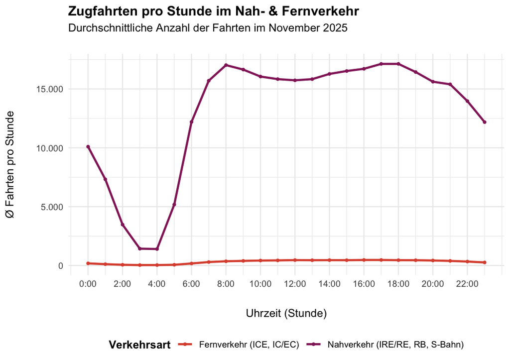

### Generelle Beschreibung und Interpretation

Das Liniendiagramm zeigt, wie viele Züge im November 2025 jeweils im Nah- und Fernverkehr pro Stunde durchschnittlich gefahren sind. Dabei zeigt die orange Linie die Fahrten der Fernverkehrszüge ICE, IC und EC, während die lilafarbene Linie den Nahverkehr visualisiert, zu dem die Zugtypen IRE, RE, RB und S-Bahn zählen.

Auffällig ist hierbei, dass zu jeder Zeit im Nahverkehr mehr Zugfahrten stattfinden. Hier sind auch größere Schwankungen des Verkehrsaufkommens zu beobachten. Zwischen 5 und 8 Uhr steigt die Anzahl der Fahrten stark von ca. 5000 Fahrten pro Stunde auf ungefähr als 17000 Fahrten pro Stunde an. Tagsüber bleibt die Anzahl der Fahrten dann zwar mit über 15000 Fahrten in der Stunde hoch, flacht aber nach der ersten Rush Hour zwischen 7 und 9 Uhr etwas ab, bevor sie von 16 bis 18 Uhr wieder ansteigt und ihren Höchstwert von ca. 17100 erreicht. Danach bricht die Durchschnittsanzahl der stündlichen Fahrten stark ein und erreicht ihren Tiefpunkt zwischen 3 und 5 Uhr nachts mit ca. 1500 Fahrten pro Stunde. Dass tagsüber mehr Fahrten angeboten werden, ist durch eine höhere Nachfrage zu begründen. Die Linie der Nahverkehrszüge wird durch das Pendleraufkommen charakterisiert, da die Peaks der Fahrtanzahlen genau mit den morgendlichen und abendlichen Hauptpendelzeiten übereinstimmen.

Im Fernverkehr hingegen fahren den ganzen Tag über weniger als 500 Züge pro Stunde. Große Schwankungen sind hier nicht zu erkennen, was auch daran liegt, dass die y-Achse einen sehr großen Wertebereich abbildet - relative Schwankungen im Fernverkehr werden somit fast nicht sichtbar. Dies könnte durch eine Logarithmierung der y-Achse behoben werden. Aber auch mit der linearen Skalierung kann man erkennen, dass die durchschnittliche Anzahl der Fahrten pro Stunde im Fernverkehr ab 5 Uhr ansteigt, ab 16 Uhr ihren Höchstwert von ca. 500 Fahrten pro Stunde erreicht und ab 19 Uhr dann wieder langsam sinkt. Der Tiefstwert wird auch hier um 3 Uhr nachts erreicht.

### Wann die meisten Züge fahren

Das Verkehrsaufkommen ist tagsüber sowohl bei Fern- als auch bei Nahverkehrszügen höher. Während im Fernverkehr um 16 Uhr mit ca. 500 Fahrten pro Stunde am meisten Züge fahren, liegt der Höchstwert im Nahverkehr bei mehr als 17000 Fahrten zwischen 17 und 18 Uhr. Auch zwischen 7 und 9 Uhr ist ein Peak der Fahrtanzahlen im Nahverkehr zu beobachten, was die Hauptverkehrszeiten der Pendler verdeutlicht. Da die Nachfrage im Fernverkehr im Tagesverlauf nicht so stark schwankt wie im Nahverkehr, schwankt das Angebot bzw. die durchschnittliche Anzahl der Zugfahrten auch nicht so stark.

### Zusammenhang mit den Verspätungen

Die Anzahl der Fahrten pro Stunde ist relevant für die Analyse der Verspätungen, weil sie eine Erklärungsmöglichkeit für etwaige Verspätungen bietet. Dabei ist insbesondere der Nahverkehr für Pendler ausschlaggebend. Aus der obigen Analyse lässt sich ableiten, dass das Schienennetz insbesondere morgens von 7-9 Uhr und abends zwischen 17 und 19 Uhr, aber auch in den Stunden dazwischen wegen des erhöhten Nahverkehrsaufkommens stark ausgelastet ist. Somit ist besonders zu diesen Uhrzeiten mit Verzögerungen zu rechnen: Nicht nur, weil es weniger freie Gleise gibt, sondern auch, weil es gerade dann zu einer Art Dominoeffekt kommen kann. Eine kleine Verspätung des einen Zuges zwingt einen anderen, zu warten. So können sich auch kleine Verzögerungen zu einer hohen Verspätung akkumulieren. Außerdem ist wichtig zu erwähnen, dass zu diesen Hauptverkehrszeiten auch am meisten Leute von den Verspätungen betroffen sind.  
Was aus dieser Grafik jedoch nicht ersichtlich wird, ist, ob die Anzahl der Fahrten am Wochenende höher oder geringer ausfällt als unter der Woche. Insbesondere im Nahverkehr wäre zu erwarten, dass am Wochenende deutlich weniger Züge fahren, weil dann weniger Pendler unterwegs sind.

### Verzerrungspotenzial bei geringer Verkehrsdichte

Abschließend ist wichtig anzumerken, dass bei der Berechnung der durchschnittlichen Verspätung pro Stunde die Zeiten, zu denen weniger Züge fahren, anfälliger für Ausreißer sind als Zeiten mit hohem Verkehrsaufkommen. Ein sehr stark verspäteter RE um 3 Uhr nachts würde die Durchschnittsverspätung stärker nach oben ziehen als einer um 17 Uhr abends, da die Anzahl der Fahrten stark abweicht. Diesen statistischen Effekt sollte man bei der nachfolgenden Analyse nicht vergessen.

Nachdem Sie in Aufgabe 6 herausgefunden haben, dass es deutlich mehr Nahverkehrszüge als Fernverkehrszüge gibt, und diese für Pendler wichtiger sind, sollten Sie sich die Verspätungen der Nahverkehrszüge über den Tag anschauen, da diese vermutlich nicht gleichmäßig über den Tag verteilt sind. Pendler erleben die Bahn vor allem in der **Hauptverkehrszeit**, d.h. morgens zwischen 7 und 9 Uhr und abends zwischen 16 und 19 Uhr. Aber ist die Bahn zu diesen Zeiten besonders unpünktlich?

7. Erstellen Sie zwei **Heatmaps**, die zeigen, wie sich die Verspätungen nach **Tageszeit** (Stunde) und **Wochentag** für die Nahverkehrszüge und die Fernverkehrszüge verteilen. Nutzen Sie für diese Analyse den Datensatz `bahn`.
- Extrahieren Sie aus der Variable `time` die Stunde und den Wochentag.
- Filtern Sie auf die **relevanten Tageszeiten** (5-23 Uhr), da nachts kaum Zugverkehr stattfindet.
- Aggregieren Sie die durchschnittliche Verspätung pro Stunde und Wochentag für Nah- und Fernverkehrszüge separat.
- Erstellen Sie eine Heatmap mit `ggplot2` und `geom_tile()`.

*Tipp zur Farbskala:* Da Fernverkehrszüge im Durchschnitt höhere Verspätungen haben als Nahverkehrszüge, können Sie **unterschiedliche Farbskalen** für die beiden Heatmaps verwenden (z.B. Blau-Töne für Nahverkehr, Rot-Töne für Fernverkehr). Dadurch werden die Muster innerhalb jeder Verkehrsart besser sichtbar.

Beschreiben und interpretieren Sie ihre Grafiken.

- Wann sind die Verspätungen am höchsten?
- Gibt es Unterschiede zwischen Werktagen und Wochenende?
- Gibt es Unterschiede zwischen Nah- und Fernverkehrszügen?
- Was bedeutet das für Pendler?

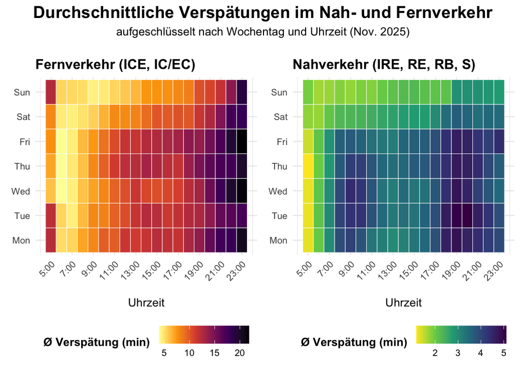

### Beschreibung und Interpretation

Die beiden Grafiken sind sogenannte Heatmaps, die die durchschnittliche Verspätung von Nah- bzw. Fernverkehrszügen im November 2025 aufgeschlüsselt nach Wochentag und Uhrzeit zeigen. Unter Nahverkehrszügen (rechte Heatmap) werden hierbei die Zugtypen RE, RB und S-Bahn betrachtet, während der Fernverkehr (linke Heatmap) durch ICEs und ICs bzw. ECs bedient wird.  
Die einzelnen Rechtecke (sog. Tiles) zeigen also die durchschnittliche Verspätung zu einer bestimmten Uhrzeit an einem bestimmten Wochentag. Dabei werden nur die Zeiten von 5 bis 23 Uhr gezeigt, also wenn das Verkehrsaufkommen - wie wir aus Aufgabe 6 bereits wissen - am höchsten ist. Die Legenden zeigen, dass die durchschnittliche Verspätung umso höher ist, je dunkler ein Tile gefärbt ist. Für die Fernverkehrszüge wird eine Farbskala von gelb (für geringe Verspätungen von maximal 5 Minuten) über orange und pink bis dunkellila (sehr hohe Verspätungen ab 20 Minuten) verwendet, während der Grad der Verspätung im Nahverkehr durch gelbe, grüne und blaue Tiles visualisiert wird.  
Wichtig anzumerken ist hierbei jedoch, dass ein dunkel gefärbtes Tile in der Heatmap der Nahverkehrszüge lediglich für eine durchschnittliche Verspätung von 5 Minuten steht, während es bei den Fernverkehrszügen eine Durchschnittsverspätung von 20 Minuten visualisiert. Für Nahverkehrszüge werden Verspätungen von 1-5 Minuten visualisiert, während die Heatmap der Fernverkehrszüge Verspätungen zwischen 5-20 Minuten farblich darstellt. Ein sehr helles Tile in der Map der Fernverkehrszüge entspricht also einem sehr dunklen bei den Nahverkehrszügen. Fernverkehrszüge haben also im Schnitt höhere Verspätungen als Nahverkehrszüge.  
Bei gesamter Betrachtung der einzelnen Heatmaps lässt sich schätzen, dass im Nahverkehr im Schnitt mit einer Verspätung von 3-4 Minuten zu rechnen ist, während Fernverkehrszüge eher eine Durchschnittsverspätung von 12-15 Minuten aufweisen. Diese Werte unterscheiden sich jedoch teilweise stark nach Uhrzeit und Wochentag, was im Folgenden näher betrachtet wird.

### Zeiten, zu denen die Verspätungen am höchsten ausfallen

Je nachdem, ob man den Nah- oder Fernverkehr betrachtet, ergibt sich hier ein unterschiedliches Bild.  
Im Fernverkehr werden die Verspätungen umso schlimmer, je später es wird - vor allem ab 20 Uhr sind die Verspätungen hoch. So haben ICEs, ICs und ECs zwischen 6 und 8 Uhr an jedem Wochentag noch weniger als 10 Minuten Verspätung; ab 20 Uhr liegt die Durchschnittsverspätung jedoch schon über 10 Minuten und um 23 Uhr haben die Züge fast jeden Tag eine durchschnittliche Verspätung von mindestens 20 Minuten.  
Im Nahverkehr sind die Verspätungen zwar auch am Ende des Tages am größten, allerdings steigen hier die durchschnittlichen Verspätungen unter der Woche bereits um 8 Uhr auf mindestens 3 Minuten an und bleiben den Rest des Tages auch auf diesem Niveau. Zwischen 18 und 20 Uhr sind die Durchschnittsverspätungen werktags dabei auf ihrem Höchststand von 4-5 Minuten. Dies ist kohärent mit den Peaks der Nahverkehrsfahrten aus Aufgabe 6. Das Schienennetz ist zu diesen Zeiten besonders stark ausgelastet, was Verspätungen begünstigt.  
Generell sollte noch erwähnt werden, dass es sich hierbei um Durchschnittsbetrachtungen handelt. Die gleiche durchschnittliche Verspätung kann entweder durch ein paar wenige, dafür aber extrem verspätete Züge (Ausreißer), oder auch durch viele moderat verspätete Züge entstehen. Je nachdem würde die Standardabweichung höher oder geringer ausfallen. Dies wird bei dieser Analyse jedoch nicht weiter beachtet.

### Unterschiede zwischen Werk- und Wochentagen

Die Unterschiede zwischen dem Wochenend- und Werktagsverkehr zeigen sich in beiden Heatmaps, jedoch besonders deutlich in der des Nahverkehrs.  
Von Montag bis Freitag sind die “Arbeitszeiten” (ca. 8–19 Uhr) stark dunkelblau gefärbt, was einer vergleichsweise hohen Durchschnittsverspätung entspricht. Am Wochenende (Samstag und Sonntag) ist die Karte fast durchgehend grün und gelb, was bedeutet, dass die Verspätungen hier geringer sind. Das liegt daran, dass ohne den Berufsverkehr das Netz weniger ausgelastet ist und “Staus” auf der Schiene ausbleiben.  
Auch im Fernverkehr ist eine geringere Verspätung am Wochenende durch eine hellere Einfärbung der entsprechenden Tiles erkennbar. Deutlicher sieht man hier aber, dass die ICEs, ICs und ECs am Donnerstag und Freitag ab 12 Uhr stärkere Verspätungen haben. Das lässt sich durch Wochenendpendler erklären.

### Unterschiede zwischen Nah- und Fernverkehr

Zwischen Nah- und Fernverkehr sind deutliche Unterschiede hinsichtlich der Verteilung der Verspätungen zu erkennen.  
Im Nahverkehr fallen die durchschnittlichen Verspätungen morgens mit 1-3 Minuten noch relativ gering aus, bis sie mit den ersten Pendlern zwischen 7 und 8 Uhr auf ein Niveau von 3-5 Minuten ansteigen und dann erst ab 21 Uhr wieder zu sinken beginnen. Besonders hoch fallen die Verspätungen zwischen 18 und 20 Uhr aus, also wenn der Arbeitstag für die meisten Pendler endet. Wegen der bereits in Aufgabe 6 erwähnten erhöhten Auslastung der Schienen zu diesen Hauptzeiten lösen Verzögerungen eher einen “Dominoeffekt” aus und lassen die Verspätungen so ansteigen. Am Wochenende sind die Verspätungszeiten wie bereits erwähnt wesentlich geringer, da keine Berufspendler unterwegs sind.  
Die Verspätungen der Fernverkehrszüge erholen sich dagegen nicht am Ende des Tages, sondern fallen dann sogar besonders hoch aus. Das liegt vor allem daran, dass sich auch kleinere Verspätungen über die langen Strecken akkumulieren. Im Lauf des Tages steigt die Auslastung der Schienen, weshalb es auch eher zu Verzögerungen kommt, die sich ansammeln. Im Vergleich zum Nahverkehr fällt hier außerdem auf, dass die Verspätungen um 5 Uhr (10-12 Minuten) im Vergleich zu denen eine Stunde später (maximal 5 Minuten) mehr als doppelt so hoch sind. Das könnte sich durch Nachtzüge, die oft gegen 5 Uhr morgens ankommen, erklären lassen.

### Fazit: Bedeutung für Pendler

Für Pendler ist der Nahverkehr insbesondere zu den Hauptzeiten zwischen 7 und 9 bzw. 16 und 19 Uhr unter der Woche wichtig. Gerade zu diesen Rush-Hours sind die Verspätungen der Nahverkehrszüge am höchsten; die Pendler müssen hier mit Verspätungen von durchschnittlich 4-5 Minuten rechnen. Insbesondere zu den abendlichen Hauptzeiten ist die Bahn dabei besonders unpünktlich. Von diesen Verspätungen sind wegen der hohen Pendlerzahlen besonders viele Menschen betroffen.  
Zu guter Letzt sollte auch noch angemerkt werden, dass die Daten der vorangegangenen Analyse kein vollständiges Bild von der Zuverlässigkeit der Bahn für die Pendler zeichnen. Ausfälle von Zügen wurden nämlich nicht in die Analyse einbezogen - diese erschweren den Pendlern jedoch den Schul- und Arbeitsweg mindestens genauso sehr wie Verspätungen.

## Von der Zeit zum Ort: Wo entstehen die Verspätungen?

In Aufgabe 7 haben Sie analysiert, **wann** die Verspätungen auftreten, nämlich vor allem zu den Hauptverkehrszeiten. Aber die nächste wichtige Frage ist: **Wo** entstehen diese Verspätungen?

Aggregierte Statistiken wie Durchschnittswerte über ganz Deutschland verbergen oft große regionale Unterschiede. Vielleicht gibt es einzelne “Problembahnhöfe”, die den Durchschnitt nach oben ziehen? Oder sind die Verspätungen gleichmäßig über das Netz verteilt? Diese Frage ist wichtig, weil sie unterschiedliche Lösungsansätze impliziert: Bei wenigen Problembahnhöfen könnte die Bahn gezielt investieren, bei flächendeckenden Problemen bräuchten Sie systemische Lösungen.

8. Identifizieren Sie die **10 unpünktlichsten Bahnhöfe** in Deutschland (mit mindestens 1.000 Halten im Monat). Nutzen Sie für diese Analyse den Datensatz `bahn`.

Erstellen Sie ein Balkendiagramm, das die durchschnittliche Verspätung dieser Bahnhöfe zeigt. Beschriften Sie die Balken mit den Verspätungswerten.

Beschreiben und interpretieren Sie ihre Grafik.

- Sehen Sie ein geografisches Muster?
- Handelt es sich um große Knotenbahnhöfe oder eher um kleinere Stationen?

[figure not shown]

### Geografisches Muster

Bei acht der zehn Bahnhöfe mit der höchsten durchschnittlichen Verspätung ist tatsächlich ein geografisches Muster in dem Sinne zu erkennen, dass mehrere Bahnhöfe auf derselben Strecke liegen.  
**Strecke Köln-Mainz (linke Rheinstrecke)**  
So werden allein sechs Bahnhöfe durch die sogenannte linke Rheinstrecke, die von Köln nach Mainz führt, miteinander verbunden. Hierbei handelt es sich um die Haltestellen Bornheim-Sechtem, Sinzig, Roisdorf, Bad Breisig, Rolandseck und Brühl, wobei die Verspätungszeiten von 13,18 Minuten bis hin zu 14,53 Minuten reichen. Verzögerungen auf der Strecke an einem Bahnhof führen wiederum zu Verspätungen am nächsten Bahnhof, wodurch eine Art Dominoeffekt gestartet wird. Ein Beleg für diese Hypothese kann in der Tatsache gefunden werden, dass die Bahnhöfe auf der linken Rheinstrecke im „Verspätungsranking“ direkt aufeinander folgen, also fast dieselbe durchschnittliche Verspätungszeit haben (geringe Varianz der Verspätungszeiten auf dem Streckenabschnitt). Im November 2025 muss es demnach vermehrt zu Verzögerungen zwischen Köln und Mainz gekommen sein. Laut der Website der Deutschen Bahn sollen 2028 auf einem Abschnitt dieser Strecke Sanierungen durchgeführt werden, weil es dort immer wieder zu „infrastrukturbedingten Störungen“ komme [^3].  
**Strecke Mönchengladbach – Köln/Koblenz**  
Auch die Bahnhöfe in Hochneukirch und Rheydt-Odenkirchen liegen auf derselben Strecke, nämlich auf der von Mönchengladbach nach Köln-Koblenz. Auch hier können sich also Verzögerungen akkumulieren, insbesondere deshalb, weil die beiden Bahnhöfe direkt aufeinander folgen. Sobald es an einem Bahnhof zu einer verzögerten Abfahrt eines Zuges kommt, wirkt sich dies auf die folgenden Bahnhöfe auf der Strecke aus.  
**Strecke Wuppertal-Hagen**  
Der Bahnhof in Ennepetal liegt zwischen Hagen und Wuppertal und stellt angesichts der Tatsache, dass es sonst kein anderer Bahnhof auf dieser Strecke in die Top 10 der Bahnhöfe mit den höchsten Verspätungen geschafft hat, vermutlich eher ein lokales Problem dar. Dieser hat mit 14,65 Minuten die höchste durchschnittliche Verspätung, was insbesondere durch die Lage von Ennepetal begründet werden kann. Die Züge, die zwischen Köln und Dortmund fahren, durchqueren fast ausschließlich diesen Ort. Bei Verspätungen haben Fernverkehrszüge meistens Vorrang vor Nahverkehrszügen, was hinsichtlich fehlender Ausweichgleise dann zu Verspätungen der Regionalzüge führt, da diese warten müssen. Ennepetal scheint unter dieser Vorrangregelung besonders zu leiden, da diese hier oft zum Einsatz kommt. Somit wird Ennepetal zum “Nadelöhr” der Region.  
**Strecke Berlin-Görlitz**  
Selbiges gilt für den Bahnhof in Zeesen, der als einziger Vertreter der Strecke Berlin-Görlitz aufgelistet wird und in Brandenburg liegt. Hier müssen Pendelnde im Durchschnitt mit der geringsten Verspätung innerhalb der Top 10 von 12,27 Minuten rechnen. Diese kommt insbesondere wegen der “ungünstigen” Lage von Zeesen zustande. Der Bahnhof folgt nämlich auf den von Königs Wusterhausen, der wiederum ein Knotenpunkt der Strecke darstellt. Auch hier führt der Vorrang des Fernverkehrs wieder dazu, dass insbesondere Regionalzüge bei überbelegten Gleisen warten müssen. Sind also zu wenig freie Gleise vorhanden, wirkt sich das massiv auf die Durchschnittsverspätungen im Zeesener Bahnhof aus.

Insgesamt liegen neun der zehn Bahnhöfe mit der höchsten Durchschnittsverspätung in Nordrhein-Westfalen und Rheinland-Pfalz: Dabei handelt es sich um alle Stationen, die entlang der linken Rheinstrecke befahren werden sowie um den Bahnhof in Ennepetal (Gevelsberg) und zwei Stationen zwischen Mönchengladbach und Köln. Dies könnte auf eine veraltete Infrastruktur insbesondere im Rhein-Ruhrgebiet hindeuten, genauso aber auch eine außergewöhnlich hohe Be- bzw. Überlastung der dortigen Strecken bedeuten. Letztere könnte insbesondere durch den Knotenbahnhof in Köln zustande kommen, der auf den meisten der oben genannten Strecken liegt.

### Größe der Bahnhöfe

Alle der obigen Bahnhöfe befinden sich zwar auf wichtigen Strecken, jedoch eher in mittelgroßen bis kleineren Städten. Somit handelt es sich vielmehr um kleinere Stationen statt um große Knotenbahnhöfe.  
Das liegt einerseits daran, dass keine dieser zehn Städte über ein S-Bahn-Netz verfügt, das auf separaten Gleisen betrieben wird. Diese sind eher in den Großstädten vorzufinden und sind meist sehr pünktlich, sodass die Durchschnittsverspätung in diesen Städten statistisch geglättet und gesenkt werden kann. Kleine bis mittelgroße Städte können von diesem statistischen Verwässerungseffekt nicht profitieren. Einzelne hohe Verspätungen wirken sich also stärker auf diese Bahnhöfe aus als auf welche mit einer höheren Haltefrequenz von Zügen.  
Zweitens halten an diesen kleineren Stationen eher Regionalzüge, die wiederum im Vergleich zum Fernverkehr nachrangig behandelt werden. Wenn also nur ein Gleis frei ist, aber sowohl ein Regionalexpress als auch ein verspäteter ICE dieses befahren wollen, muss der Regionalexpress warten. Dazu kommen oftmals noch Güterzüge, die die Auslastung der Gleise noch weiter erhöhen, da Güter- und Personenverkehr in Deutschland dasselbe Schienennetz befahren. Auf sehr stark belasteten Strecken wie der linken Rheinstrecke kommt dies wahrscheinlich häufiger vor, was sich dann in einer hohen durchschnittlichen Verspätung bei den kleinen Stationen auf der Strecke widerspiegelt. Orte wie Roisdorf, Bad Breisig oder Brühl sind somit „Leidtragende“ von Verspätungen, die durch Vorrangregelungen (Fernverkehr vor Nahverkehr) auf die Kleinstationen abgewälzt werden.

### Fazit

Zusammenfassend lässt sich die Eingangsfrage klar beantworten: Es handelt sich bei den Top-10-Bahnhöfen nicht um isolierte “Problembahnhöfe”, sondern um die Leidtragenden überlasteter Strecken und Vorrangregelungen. Da die Verspätungen clusterartig auf ganzen Streckenabschnitten (z. B. linke Rheinstrecke) auftreten, würden lokale Investitionen in einzelne Bahnhöfe (z. B. nur in Roisdorf) das Problem nicht lösen. Stattdessen sind andere Lösungen wie der Streckenausbau oder die Entflechtung von Fern- und Nahverkehr auf den identifizierten Korridoren notwendig.

# Wo treffen viele Pendler auf eine unpünktliche Bahn?

Bisher haben Sie Pendler- und Bahndaten getrennt betrachtet. Aber die spannende Frage ist: **Wo kommen beide Probleme zusammen?** Eine Stadt mit vielen Pendlern und einer unpünktlichen Bahn hat ein größeres Problem als eine Stadt mit wenigen Pendlern und einer unpünktlichen Bahn.

Um diese Frage zu beantworten, müssen Sie die Datensätze verknüpfen. Das Problem: Die Bahndaten sind auf Bahnhofsebene, die Pendlerdaten auf Kreisebene. Sie benötigen ein **Mapping**, das Bahnhöfe den entsprechenden Kreisen zuordnet.

9. In dieser Aufgabe verknüpfen Sie die Bahn- und Pendlerdaten, um Städte mit Handlungsbedarf zu identifizieren. Nutzen Sie für ihre Analysen die Datensätze: `bahn`, `pendler` und `bahnhof_mapping`.

Das Mapping ordnet Bahnhöfe ihrem Landkreis zu (via AGS = Amtlicher Gemeindeschlüssel). Ihr Ziel: Identifizieren Sie Städte, in denen **viele Pendler auf eine unpünktliche Bahn** treffen.

- Berechnen Sie für jeden Bahnhof die durchschnittliche Verspätung und die Anzahl der Halte.
- **Aggregation auf Kreisebene:** Berechnen Sie für jeden Kreis die **gewichtete durchschnittliche Verspätung**. Gewichten Sie nach der Anzahl der Halte (ein Bahnhof mit 10.000 Halten zählt mehr als einer mit 100).
- Verknüpfen Sie das Ergebnis mit den Pendlerdaten mittels `left_join()` über die Variable `ags`.
- **Problem-Score berechnen:** Kombinieren Sie beide Dimensionen mit z-Standardisierung:

$$\text{Problem-Score} =
z(\text{Einpendler}) + z(\text{Verspätung})$$

Die z-Standardisierung macht die Werte vergleichbar: $z(x) = \frac{x - \bar{x}}{s_x}$, wobei $\bar{x}$ der Mittelwert und $s_x$ die Standardabweichung ist.

**Interpretation:** Ein hoher Problem-Score = Viele Pendler + hohe Verspätung = **Handlungsbedarf**.

Anschließend sollten Sie eine Tabelle der **Top 10 Städte** nach Problem-Score darstellen und diese kurz beschreiben.

Top 10 Landkreise mit den problematischsten Bahnhöfen für Pendler

anhand von Verspätungen und Anzahl der Einpendler im November 2025 sortiert nach Problem-Score

| Landkreis | Problem-Score | gewichtete durchschn. Verspätung (min)* | z-Score (Verspätung) | Einpendler (Anzahl) | z-Score (Pendler) |
| --- | --- | --- | --- | --- | --- |
| München | 3,45 | 5,98 | 0,18 | 455.645 | 3,27 |
| Köln | 3,06 | 7,89 | 1,19 | 306.905 | 1,87 |
| Düsseldorf | 2,55 | 7,33 | 0,89 | 284.696 | 1,66 |
| Frankfurt | 2,54 | 5,14 | −0,26 | 405.856 | 2,80 |
| Berlin | 2,18 | 4,70 | −0,49 | 392.324 | 2,67 |
| Hamburg | 2,05 | 4,44 | −0,63 | 392.951 | 2,68 |
| Duisburg | 1,46 | 8,81 | 1,67 | 86.735 | −0,21 |
| Hamm | 1,44 | 9,93 | 2,26 | 22.447 | −0,82 |
| Stuttgart | 1,38 | 5,30 | −0,18 | 274.442 | 1,56 |
| Bonn | 1,27 | 8,00 | 1,24 | 112.607 | 0,03 |

**Berechnung des Problem-Scores:** Addition der z-standardisierten Werte von Einpendlern und Verspätung.  
*Gewichtung der durchschnittlichen Verspätung nach Gesamtanzahl der Halte in den Bahnhöfen eines Landkreises

### Beschreibung und Interpretation

**Beschreibung**  
Die Tabelle listet die 10 Landkreise in Deutschland auf, in denen im November 2025 am meisten zeitlicher Schaden durch Verspätungen von Zügen entstanden ist. Die Kreise wurden dabei absteigend nach einem Problem-Score sortiert, der durch Addition der z-standardisierten Werte von Einpendleranzahl und der Durchschnittsverspätung von Zügen in allen Bahnhöfen des entsprechenden Landkreises errechnet wurde. Somit beeinflussen sowohl die Anzahl der Einpendler als auch die Höhe der durchschnittlichen Verspätung den Problem-Score. Die Durchschnittsverspätung wurde dabei nach Anzahl der Halte in dem jeweiligen Landkreis gewichtet, was für die Anzahl der fahrenden Züge im Kreis korrigiert.  
Es werden ausschließlich Kreise, in denen Großstädte liegen, aufgeführt. Das liegt größtenteils daran, dass dort überdurchschnittlich viele Einpendler mit der Bahn fahren. Die Anzahl der Pendler liegt dabei in 8 von 10 Kreisen über 100 Tsd. - angeführt von München, Frankfurt und Hamburg mit jeweils ca. 456 Tsd., 406 Tsd. und 393 Tsd. Einpendlern. Duisburg und Hamm bilden mit jeweils knapp 87 Tsd. bzw. 22 Tsd. Einpendlern die Ausnahme. Demnach ist zu erwarten, dass in diesen beiden Bahnhöfen die Verspätungen überdurchschnittlich hoch sind - sonst würde der Problem-Score dort um einiges geringer ausfallen.  
Die gewichteten Durchschnittsverspätungen reichen von 4,44 bis 9,93 Minuten und fallen in Hamm (9,93 min), Duisburg (8,81 min) und Bonn (8,00 min) am höchsten aus. Vor allem in Hamm und Duisburg scheint die Deutsche Bahn also mit dem vergleichsweise geringen Verkehrsaufkommen überfordert zu sein.

10. Erstellen Sie ein **Streudiagramm (Scatterplot)**, das die Beziehung zwischen Einpendlerzahl (x-Achse) und durchschnittlicher Verspätung (y-Achse) visualisiert.
- Zeichnen Sie horizontale und vertikale Linien beim jeweiligen Mittelwert ein, um **4 Quadranten** zu bilden
- Färben Sie die Punkte nach Quadrant
- Beschriften Sie die Städte mit den höchsten Problem-Scores
- Nutzen Sie eine logarithmische Skala für die x-Achse

Beschreiben und interpretieren Sie die vier Quadranten:

- **Oben rechts:** Viele Pendler + hohe Verspätung = ?
- **Oben links:** Wenige Pendler + hohe Verspätung = ?
- **Unten rechts:** Viele Pendler + niedrige Verspätung = ?
- **Unten links:** Wenige Pendler + niedrige Verspätung = ?

Beantworten Sie dabei auch folgende Fragen:

- Warum ist es sinnvoll die x-Achse zu logarithmieren?
- Welche Städte liegen im kritischen Quadranten?
- Was würden Sie der Deutschen Bahn empfehlen?

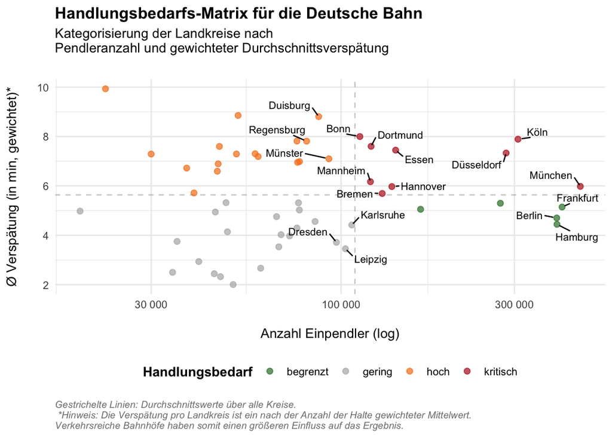

### Aufbau und Beschreibung des Streudiagramms

Das dargestellte Streudiagramm visualisiert die Beziehung zwischen der Anzahl der Einpendler und der gewichteten durchschnittlichen Verspätung der Züge in den jeweiligen Landkreisen. Jeder Punkt im Diagramm repräsentiert dabei einen Landkreis.  
Horizontal wird die Anzahl der Einpendler dargestellt, die als Maß für die Relevanz und das potenzielle Schadensausmaß von Verspätungen interpretiert werden kann. Die y-Achse zeigt die nach Anzahl der Halte im Landkreis gewichtete durchschnittliche Verspätung in Minuten und dient als Indikator für die Zuverlässigkeit des Bahnverkehrs.  
Zur Strukturierung des Diagramms wurden sowohl horizontal als auch vertikal Linien bei den jeweiligen Mittelwerten eingezeichnet, sodass eine “Handlungsbedarfs-Matrix” entsteht. Dieser Handlungsbedarf wird an den beiden Dimensionen Einpendleranzahl und Durchschnittsverspätung gemessen. Der Mittelwert der Einpendler liegt bei etwa 110.000, der der gewichteten Durchschnittsverspätung bei rund 5,5 Minuten. Diese vier Quadranten der Matrix kategorisieren die Landkreise jeweils danach, wie dringend die Deutsche Bahn in den jeweiligen Kreisen Maßnahmen zur Verbesserung des Zugverkehrs unternehmen sollte. Die Punkte sind entsprechend ihres Quadranten bzw. der Dringlichkeit des Handlungsbedarfs farblich codiert: Rote Punkte stehen für Landkreise, in denen das Ausmaß des Schadens durch Verspätungen kritisch ist und Maßnahmen dringend nötig sind, gelbe für einen hohen, aber nicht ganz so dringenden Handlungsbedarf, grüne Punkte repräsentieren einen begrenzten Bedarf für Maßnahmen und graue Punkte stehen für die Landkreise, in denen die Notwendigkeit für Maßnahmen eher gering ist. Zusätzlich sind alle Städte, bei denen dringlicher Handlungsbedarf besteht, sowie die drei jeweils einpendlerstärksten Kreise der anderen Quadranten direkt im Diagramm beschriftet.

### Logarithmische Skalierung der x-Achse

Die Verwendung einer logarithmischen Skala für die x-Achse ist aus statistischer und visueller Sicht sinnvoll. Die Verteilung der Einpendlerzahlen ist stark rechtsschief: Es existieren wenige Kreise mit hohen Einpendlerzahlen wie München, Frankfurt oder Berlin, während der Großteil der Landkreise deutlich geringere Werte aufweist. Diese rechtsschiefe Verteilung kann man daran erkennen, dass weniger Punkte rechts von der vertikalen Linie, die den Mittelwert der Einpendler darstellt, liegen als links davon. Demnach muss der Medianwert der Einpendleranzahl unterhalb des arithmetischen Mittels liegen, was Rechtsschiefe impliziert.  
Bei einer linearen Skalierung der x-Achse würden die wenigen “Einpendler-Metropolen” weit rechts im Diagramm liegen, während die restlichen Kreise stark zusammengedrängt nahe der y-Achse erscheinen würden. Dies hätte zur Folge, dass Unterschiede zwischen kleineren und mittleren Städten visuell kaum noch erkennbar wären. Auch die Mittelwertslinie würde weiter links statt wie bei der log-Skalierung zentral in der Mitte liegen.  
Durch die Logarithmierung wird der Wertebereich also entzerrt. Dadurch werden relative Unterschiede auch bei geringeren Einpendlerzahlen sichtbar, und das Streudiagramm eignet sich besser für eine vergleichende Analyse über alle Regionen hinweg.

### Handlungsempfehlungen für die Deutsche Bahn

Aus der Analyse lassen sich drei Prioritäten für die Deutsche Bahn ableiten. Wichtig anzumerken ist, dass die Deutsche Bahn durch Maßnahmen nur Einfluss auf die Durchschnittsverspätungen nehmen kann, nicht direkt auf die Zahl der Einpendler.  
Erste Priorität sollte der rote Quadrant, insbesondere der Ruhrgebiets-Cluster, haben. Investitionen in Infrastruktur, Betriebsstabilität und Kapazitätsausbau wirken hier doppelt: Sie senken hohe Verspätungen und entlasten gleichzeitig hunderttausende Pendler. Der potenzielle Nutzen pro investiertem Euro ist in diesem Quadranten am höchsten, da es wahrscheinlich ist, dass bestimmte Strecken die hohen Verspätungen verursachen.  
Zweite Priorität ist die Sicherung der Stabilität in den großen, aktuell mit geringen Verspätungen gesegneten Metropolen des grünen Quadranten wie beispielsweise Frankfurt. Diese Städte sind aufgrund ihrer Größe „too big to fail“. Eine Verschlechterung der Infrastruktur bzw. eine Erhöhung der Verspätung würde sofort zu extrem hohen Zeitverlusten und volkswirtschaftlichen Kosten führen. Präventive Instandhaltung und Resilienzmaßnahmen sind hier also entscheidend.  
Die Städte im orangefarbenen Quadranten sollten ebenfalls adressiert werden, da die hohen Verspätungen auf ernsthafte operative Defizite im Bahnkonzern hinweisen und sich auch zu höheren Verspätungen in anderen Gebieten führen können, wenn sich diese kumulieren. Aus gesamtwirtschaftlicher Sicht besitzen sie jedoch eine etwas geringere Priorität als die großen Ballungsräume, da weniger Pendler betroffen sind.  
Insgesamt zeigt das Streudiagramm, dass eine rein qualitative Betrachtung von Verspätungen nicht ausreicht. Erst die gemeinsame Analyse von Verkehrsmenge und Qualität ermöglicht eine fundierte, datengetriebene Priorisierung von Maßnahmen.

# Der Vergleich – Auto vs. Bahn

Sie haben nun identifiziert, **wo** die Bahn Probleme hat: Städte im kritischen Quadranten (viele Pendler + hohe Verspätungen) brauchen dringend Verbesserungen. Aber bevor Sie Empfehlungen aussprechen können, müssen Sie eine zentrale Frage beantworten:

> **Lohnt sich die Bahn überhaupt – oder ist das Auto trotz Stau schneller?**

Denn selbst wenn die Bahn unpünktlich ist, könnte sie immer noch schneller sein als das Auto im Berufsverkehr. Umgekehrt: Eine pünktliche Bahn bringt wenig, wenn das Auto trotzdem schneller ist. Erst der **direkte Vergleich** zeigt uns, wo die Bahn wirklich konkurrenzfähig ist – und wo nicht.

## Methodische Herausforderungen

Für einen fairen Vergleich sollten Sie “Äpfel mit Äpfeln” vergleichen:

- Beim **Auto** muss der Stau berücksichtigt werden (nicht nur die theoretische Fahrzeit)
- Bei der **Bahn** muss die Verspätung berücksichtigt werden (nicht nur der Fahrplan)
- Beide Routen müssen **dieselben Start- und Endpunkte** haben

Für die Auto-Fahrtzeiten nutzen Sie **OSRM** (Open Source Routing Machine), das auf OpenStreetMap-Daten basiert. OSRM berechnet echte Straßenrouten, keine Luftlinien.

11. Erklären Sie in eigenen Worten:
- Warum ist OSRM-Routing für diesen Vergleich besser geeignet als eine einfache Berechnung nach der Formel `Distanz / Geschwindigkeit`?
- Welche Faktoren müssen zusätzlich berücksichtigt werden, um einen realistischen Vergleich zu ermöglichen? Denken Sie an:
  - Tageszeit
  - Parkplatzsuche
  - Fußweg zum Ziel
  - Wartezeit und Umsteigen bei der Bahn

### Vergleich von OSRM mit Distanz/Geschwindigkeit

OSRM (Open Source Routing Machine) ist ein Routenplaner, der auf OpenStreetMap-Daten basiert und für gegebene Start- und Zielpunkte reale Fahrtrouten über das bestehende Straßennetz berechnet. Für den Vergleich zwischen Auto und Bahn ist ein Routing mit OSRM deutlich besser geeignet als eine einfache Berechnung nach dem Prinzip Distanz dividiert durch Geschwindigkeit, da diese Formel die tatsächliche Verkehrssituation nicht realsistisch darstellt. Sie geht von einer idealisierten, direkten Strecke und einer konstanten Durchschnittsgeschwindigkeit aus und ignoriert dabei wichtige Aspekte des Straßenverkehrs wie das tatsächliche Straßennetz, Kreuzungen, Ampeln, Abbiegevorgänge und Umwege. OSRM hingegen nutzt reale OpenStreetMap-Daten und berechnet konkrete Routen auf Basis des bestehenden Straßennetzes. Dadurch entstehen Fahrzeiten, die deutlich näher an der tatsächlichen Autonutzung liegen und somit besser mit den realen Bahnfahrzeiten vergleichbar sind.

Für einen wirklich realistischen Vergleich müssen jedoch über die reine Fahrzeit hinaus weitere Faktoren berücksichtigt werden. Die Tageszeit spielt eine zentrale Rolle, da sowohl Staus im Autoverkehr als auch Verspätungen bei der Bahn besonders im Berufsverkehr auftreten. Zusätzlich fällt beim Auto oft Zeit für die Parkplatzsuche an, die je nach Stadt und Tageszeit enorm sein kann und in klassischen Routenberechnungen nicht enthalten ist. Sowohl beim Auto als auch bei der Bahn müssen außerdem Fußwege einbezogen werden, etwa vom Parkplatz oder Bahnhof bis zum eigentlichen Ziel. Auf Seiten der Bahn kommen zudem Wartezeiten vor der Abfahrt, Zeitverluste durch Umsteigen sowie das Risiko verpasster Anschlüsse hinzu, die sich bei Verspätungen weiter verstärken können. Erst wenn all diese Aspekte berücksichtigt werden, lässt sich beurteilen, ob die Bahn im Alltag tatsächlich eine konkurrenzfähige Alternative zum Auto darstellt.

12. Für die Top 10 Einpendler-Städte wurden typische Pendlerstrecken definiert (z.B. Dachau $\rightarrow$ München, Neuss $\rightarrow$ Düsseldorf). Die OSRM-Ergebnisse liegen bereits vor. Nutzen Sie für ihre Analyse den Datensatz `fahrtzeit`.

Erstellen Sie:

- Eine **Tabelle** mit: Stadt, Strecke, Distanz (km), Auto-Fahrzeit (Hauptverkehrszeit), Bahn-Fahrzeit (real), Differenz
- Berechnen Sie die **jährliche Zeitersparnis** bei 220 Arbeitstagen und 2x täglichem Pendeln.

Interpretieren Sie ihre Tabelle:

- In wie vielen Fällen ist die Bahn schneller als das Auto?
- Wie viele Stunden pro Jahr kann ein Pendler maximal sparen?
- Gibt es Strecken, bei denen das Auto schneller ist? Woran könnte das liegen?

Vergleich Auto- und Bahnfahrzeit für Top-10-Einpendler-Städte

| Stadt | Strecke | Distanz (km) | Auto-Fahrzeit | Bahn-Fahrzeit (real) | Differenz (min) | Jährliche Zeitersparnis (h)<sup>1</sup> |
| --- | --- | --- | --- | --- | --- | --- |
| Berlin | Potsdam → Berlin | 34,20 | 49,30 | 29,58 | 19,72 | 144,63 |
| München | Dachau → München | 19,10 | 40,20 | 26,08 | 14,12 | 103,53 |
| Hannover | Celle → Hannover | 42,20 | 54,40 | 40,80 | 13,60 | 99,76 |
| Frankfurt | Darmstadt → Frankfurt | 36,00 | 35,80 | 23,00 | 12,80 | 93,90 |
| Düsseldorf | Neuss → Düsseldorf | 12,10 | 27,10 | 17,10 | 10,00 | 73,35 |
| Hamburg | Harburg → Hamburg | 14,20 | 24,00 | 16,27 | 7,73 | 56,71 |
| Stuttgart | Esslingen → Stuttgart | 14,00 | 27,20 | 20,17 | 7,03 | 51,55 |
| Nürnberg | Fürth → Nürnberg | 10,40 | 18,90 | 12,85 | 6,05 | 44,37 |
| Köln | Leverkusen → Köln | 18,30 | 28,70 | 22,79 | 5,91 | 43,32 |
| Essen | Mülheim → Essen | 11,00 | 18,00 | 15,27 | 2,73 | 20,05 |
| Ulm | Neu-Ulm → Ulm | 3,70 | 8,10 | 8,89 | −0,79 | −5,77 |

<sup>1</sup> Jährliche Zeitersparnis geht von 220 Arbeitstagen und zwei Pendlerwegen pro Tag im Jahr aus

### Interpretation der Tabelle

Die oben gezeigte Tabelle vergleicht die Fahrzeiten mit Bus und Auto für die zehn größten Pendlerstädte Deutschlands und bezieht zusätzlich Ulm mit ein. Sie enthält die jeweilige Entfernung in Kilometern sowie die Fahrzeiten mit der Bahn und dem Auto zu Hauptverkehrszeiten. Auf Basis dieser Daten wird die tägliche Zeitdifferenz zwischen den beiden Verkehrsmitteln berechnet, aus der sich anschließend die jährliche Zeitersparnis für Pendler ableiten lässt.

In der Tabelle weist die Strecke Potsdam → Berlin mit rund 145 Stunden die mit Abstand höchste jährliche Zeitersparnis auf, wenn statt des Autos die Bahn genutzt wird. An zweiter Stelle folgt die Verbindung Dachau → München mit einer jährlichen Zeitersparnis von ungefähr 104 Stunden. Diese hohen Werte verdeutlichen, dass sich selbst scheinbar moderate Zeitunterschiede pro Fahrt durch die hohe Anzahl an Pendeltagen im Jahr zu erheblichen Einsparungen summieren. Bei einer genaueren Betrachtung der Tabelle lässt sich ein strukturelles Muster erkennen: Mit zunehmender Distanz steigt in vielen Fällen auch der Zeitvorteil der Bahn gegenüber dem Auto. Dies deutet darauf hin, dass der Straßenverkehr insbesondere auf längeren Pendelstrecken stärker durch externe Einflussfaktoren wie Verkehrsaufkommen, Staus oder Unfälle beeinträchtigt wird. Der Schienenverkehr hingegen profitiert von einem eigenen, weitgehend vom Straßenverkehr getrennten Netz und kann seine Fahrzeiten daher konstanter einhalten. Besonders im Berufsverkehr führt diese höhere Planbarkeit zu einem messbaren Zeitvorteil.

Auffällig ist zudem, dass die Bahn ihren Vorteil nicht nur auf sehr langen Strecken ausspielt, sondern auch auf mittleren Distanzen zwischen 15 und 40 Kilometern, die für viele Pendler typisch sind. Ursache dafür ist weniger die Entfernung als vielmehr die Verkehrsbelastung: Gerade in diesem Bereich führen Staus und Engstellen zu stark verlängerten Autofahrzeiten. Diese Verzögerungen machen auf mittleren Strecken einen besonders großen Anteil der Gesamtfahrzeit aus. Die Bahn ist davon weitgehend unabhängig und kann ihre Fahrzeiten meist stabiler einhalten. Zudem sind S-Bahn- und Regionalverbindungen häufig genau auf diese Distanzen ausgelegt, mit direkter Linienführung und hoher Taktung, was ihren Zeitvorteil zusätzlich verstärkt.

Bemerkenswert ist außerdem, dass nur in einem von elf Fällen das Auto schneller ist als die Bahn, nämlich auf der vergleichweise kurze Strecke Neu-Ulm → Ulm. Die daraus resultierende Zeitersparnis zugunsten des Autos ist mit nur 5,77 Stunden pro Jahr jedoch vernachlässigbar. Dies lässt sich dadurch erklären, dass bei sehr kurzen Distanzen Bahnfahrten durch Wartezeiten und Zugangswege relativ gesehen an Effizienz verlieren, während das Auto hier seine Flexibilität ausspielen kann. Insgesamt lässt sich allerdings festhalten, dass sich in den meisten Fällen die Nutzung der Bahn stärker lohnt als die Wahl des Autos.

13. Da Sie alle in Ulm studieren und eventuell aus dem Ulmer Umland einpendeln, sollten Sie die **5 wichtigsten Pendlerrouten nach Ulm** näher analysieren. Stellen Sie in einem **Dumbbell-Chart** (oder Lollipop-Chart) die Unterschiede zwischen Auto- und Bahnzeiten visuell dar. Nutzen Sie für ihre Analyse den Datensatz `ulm_routen`.

Die 5 wichtigsten Pendlerrouten nach Ulm sind:

- Neu-Ulm $\rightarrow$ Ulm
- Blaustein $\rightarrow$ Ulm
- Ehingen $\rightarrow$ Ulm
- Laupheim $\rightarrow$ Ulm
- Langenau $\rightarrow$ Ulm

Markieren Sie, welche Orte **keinen Bahnhof** haben.

Beschreiben und interpretieren Sie ihre Grafik. Welche Besonderheiten zeigen die ländlichen Strecken?

*Hinweis:* Nutzen Sie `geom_segment()` und `geom_point()` für ihr [Dumbbell-Chart](https://r-graph-gallery.com/web-dumbbell-chart-with-a-gap-column.html) oder [Lollipop-Chart](https://r-graph-gallery.com/303-lollipop-plot-with-2-values.html).

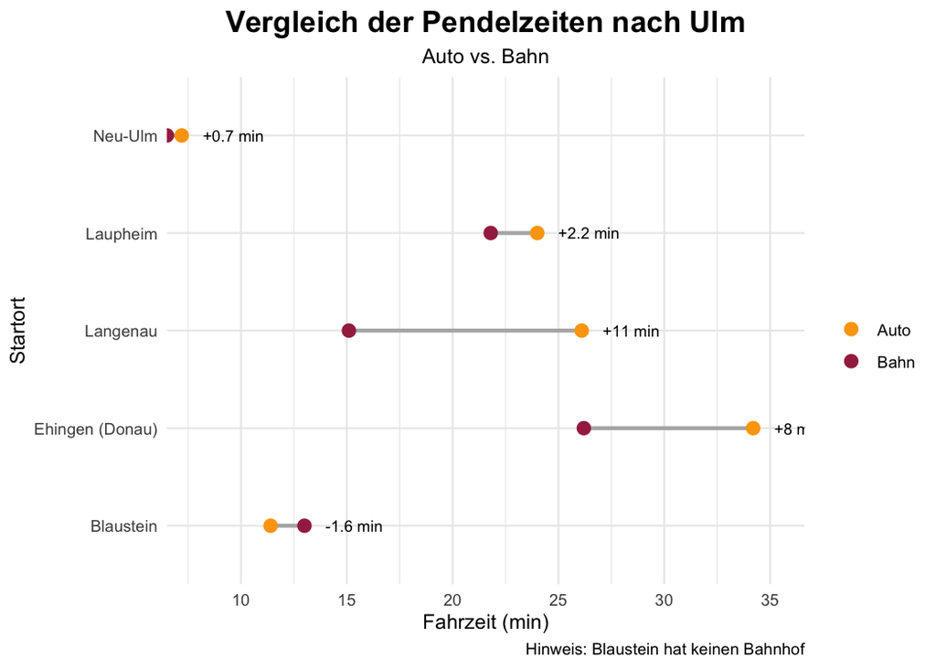

### Beschreibung und Interpretation

**Beschreibung**

Das dargestellte Dumbbell-Chart vergleicht die Pendelzeiten der fünf wichtigsten Pendlerrouten nach Ulm für die Verkehrsmittel Auto und Bahn. Auf der Y-Achse sind die fünf Städte als Startorte aufgeführt, während die X-Achse die jeweilige Fahrzeit in Minuten zeigt. Die orangenen Punkte markieren die Fahrzeiten mit dem Auto, die dunkelroten Punkte jene mit der Bahn. Die graue Verbindungslinie zwischen den Punkten visualisiert die zeitliche Differenz zwischen beiden Fortbewegungsmitteln.

**Interpretation**

Für die stadtnahen Strecken zeigt sich nur ein geringer Zeitunterschied. Besonders bei Neu-Ulm → Ulm liegen Auto- und Bahnfahrzeit fast gleichauf mit nichtmal einer Minute Zeitunterschied, was auf die sehr kurze Distanz und die gute Verkehrsinfrastruktur zurückzuführen ist. Auch bei Blaustein → Ulm sind die Unterschiede gering - hier ist das Auto nur 1,6 Minuten schneller als die Bahn.

Bei den ländlicheren Pendlerrouten fallen die Unterschiede deutlicher aus. Auf den Strecken Ehingen → Ulm und Langenau → Ulm ist die Bahn deutlich schneller als das Auto. Insbesondere bei Langenau ergibt sich ein erheblicher Zeitvorteil der Bahn von 11 Minuten, was auf eine direkte und gut ausgebaute Bahnverbindung sowie auf mögliche Stauanfälligkeit des Autoverkehrs hindeutet. Auch von Ehingen aus bietet die Bahn einen klaren Zeitvorteil mit 8 Minuten Unterschied.

Ein wichtiger Aspekt der Analyse ist die Bahnhofsanbindung: Blaustein verfügt über keinen eigenen Bahnhof, was die vergleichsweise längere Bahnfahrzeit erklärt, da zusätzliche Wege oder Umstiege notwendig sind. Dies zeigt exemplarisch eine Besonderheit ländlicher Strecken: Fehlt eine direkte Schienenanbindung, verliert die Bahn an Attraktivität gegenüber dem Auto.

Zusammenfassend verdeutlicht die Grafik, dass die Bahn auf gut angebundenen ländlichen Strecken deutliche Zeitvorteile bietet, während auf kurzen oder schlecht angebundenen Strecken das Auto konkurrenzfähig oder sogar schneller ist. Die Wahl des Verkehrsmittels hängt somit stark von der Infrastruktur und der Anbindung des jeweiligen Startortes ab.

# Die volkswirtschaftlichen Kosten

Verspätungen kosten nicht nur Nerven, sie haben einen **realen volkswirtschaftlichen Preis**. Jede Minute, die ein Pendler im verspäteten Zug wartet, ist verlorene Arbeitszeit.

Um diese Kosten etwas besser zu quantifizieren sollten Sie sich den **Medianlohn** der jeweiligen Städte herunterladen und näher analysieren.

14. Berechnen Sie die volkswirtschaftlichen Kosten der Bahnverspätungen für die 11 Städte.

**Datensätze:**

- `staedte_basis` (aus Aufgabe 4) – enthält Einpendler, Medianlohn und Staudaten
- Ergebnis aus Aufgabe 9: die **gewichtete durchschnittliche Verspätung pro Stadt** (in Minuten)

Nutzen Sie die folgenden Annahmen:

**Annahmen:**

- 220 Arbeitstage pro Jahr
- 2 Fahrten pro Tag (Hin + Zurück)
- Ca. 8,4% der Pendler nutzen die Bahn (nationaler Durchschnitt laut [MiD 2023 Kurzbericht](https://www.mobilitaet-in-deutschland.de/pdf/MiD2023_Kurzbericht.pdf))

Berechnen Sie für jede Stadt:

- Anzahl der Bahnpendler (Einpendler × 8,4%)
- Verspätungsstunden pro Jahr (Verspätung × 220 × 2 / 60)
- Kosten pro Pendler (Verspätungsstunden × Stundenlohn)
- Gesamtkosten der Stadt

Erstellen Sie auf Basis ihrer Berechnung eine Tabelle, welche die Anzahl der Bahnpendler, die Verspätungsstunden pro Jahr, die Kosten pro Pendler und die Gesamtkosten der Stadt anschaulich darstellt.

Beschreiben und interpretieren Sie ihre Tabelle. Gehen Sie dabei auch auf die Gesamtkosten der 11 Städte ein. Erklären Sie außerdem, warum der **Medianlohn** für diese Berechnung besser geeignet ist als der Durchschnittslohn.

*Hinweis:* Für die Umrechnung auf Stundenlohn: Monatsentgelt / 160 (bei 40h/Woche).

Volkswirtschaftliche Kosten für Verspätungen der Bahn pro Stadt

| Stadt | Bahnpendler | Verspätung/Jahr (h) | Kosten/Pendler (€) | Gesamtkosten (in Mio.€) |
| --- | --- | --- | --- | --- |
| München | 38.274 | 43,9 | 1.329 | 50,87 |
| Köln | 25.780 | 57,9 | 1.591 | 41,02 |
| Frankfurt | 34.092 | 37,7 | 1.112 | 37,91 |
| Düsseldorf | 23.914 | 53,8 | 1.520 | 36,35 |
| Hamburg | 33.008 | 32,6 | 923 | 30,47 |
| Berlin | 32.955 | 34,5 | 896 | 29,53 |
| Stuttgart | 23.053 | 38,9 | 1.139 | 26,26 |
| Essen | 11.869 | 54,6 | 1.362 | 16,17 |
| Nürnberg | 13.902 | 37,1 | 981 | 13,64 |
| Hannover | 11.586 | 43,8 | 1.138 | 13,18 |
| Ulm | 5.741 | 29,5 | 796 | 4,57 |

### Beschreibung und Interpretation

**Beschreibung**

Die Tabelle zeigt die volkswirtschaftlichen Kosten von Bahnverspätungen für elf deutsche Städte. Sie enthält die Anzahl der Bahnpendler, die durchschnittliche Verspätung der Bahn pro Jahr in Stunden, die Kosten pro Pendler sowie die Gesamtkosten für die jeweilige Stadt.

**Interpretation**

Aus der Tabelle wird deutlich, dass die volkswirtschaftlichen Gesamtkosten von Bahnverspätungen nicht allein von der Anzahl der Pendler abhängen, sondern beeinflusst werden durch die durchschnittliche jährliche Verspätung sowie das Lohnniveau, gemessen am Medianlohn. Besonders anschaulich zeigt sich dies am Beispiel München: Mit rund 50,9 Mio. Euro weist die Stadt die höchsten Gesamtkosten auf. Dies ist darauf zurückzuführen, dass München sowohl eine höchste Anzahl an Bahnpendlern als auch relativ hohe Kosten pro Pendler aufweist, die wiederum durch das hohe Einkommensniveau bedingt sind.

Den zweithöchsten Wert erreicht Köln mit etwa 41 Mio. Euro. Obwohl dort um rund ein Drittel weniger Bahnpendler betroffen sind als in München, entstehen die hohen Gesamtkosten vor allem durch die im Vergleich höchsten durchschnittlichen Verspätungen der zehn Städte sowie durch die ebenfalls höchsten Kosten pro Pendler. Dieses Beispiel verdeutlicht, dass selbst bei geringeren Pendlerzahlen erhebliche volkswirtschaftliche Schäden entstehen können, wenn Verspätungen häufig auftreten und die Kosten pro Pendler sehr hoch sind.

In dieser Tabelle wird der Medianlohn verwendet, um die Kosten pro Pendler zu berechnen. Diese Methode erweist sich für diese Analyse als besonders geeignet. Im Gegensatz zum Durchschnittslohn, der durch sehr hohe oder sehr niedrige Einkommen einzelner Personen verzerrt werden kann, bildet der Medianlohn den typischen Verdienst der Pendler realitätsnah ab.

Insgesamt macht die Analyse deutlich, dass Bahnverspätungen nicht nur ein individuelles Ärgernis für Pendler darstellen, sondern erhebliche volkswirtschaftliche Kosten verursachen, die je nach Stadt stark variieren. Besonders hohe Belastungen entstehen dort, wo lange Verspätungen auf ein hohes Lohnniveau treffen. Die Ergebnisse unterstreichen damit die wirtschaftliche Relevanz von Investitionen in eine zuverlässigere und leistungsfähigere Bahninfrastruktur, insbesondere in Regionen mit hohem Pendleraufkommen.

15. Setzen Sie die Kosten der Bahn (aus Aufgabe 14) den Kosten des Autos gegenüber. Vergleichen Sie diese in einer Szenario-Analyse mittels eines gestapelten Balkendiagramms. Nutzen Sie für ihre Analysen den Datensatz `staedte_basis`.

Berechnen Sie zuerst die Kosten des Autostaus pro Stadt:

- Anzahl der Autopendler (Einpendler × 91,6%)
- Staukosten pro Autopendler (Staustunden × Stundenlohn)
- Gesamtkosten der Stadt durch Autostau

Führen Sie anschließend einen Szenario-Vergleich durch: Was passiert, wenn der Bahnanteil von 8,4% auf 20% steigt?

- Berechnen Sie die Gesamtkosten (Bahn + Auto) für beide Szenarien
- *Annahme:* Weniger Autos = weniger Stau (z.B. 20% weniger Stauzeit pro Autopendler)

Erstellen Sie ein gestapeltes Balkendiagramm nach Szenario. Beschreiben und intepretieren Sie ihre Grafik. Gehen Sie insbesondere auf die folgenden Fragen ein:

- Wie verteilen sich die Kosten zwischen Bahn und Auto im Status quo?
- Welches Verkehrsmittel verursacht den größeren volkswirtschaftlichen Schaden?
- Was ist die Nettoersparnis bei 20% Bahnanteil?

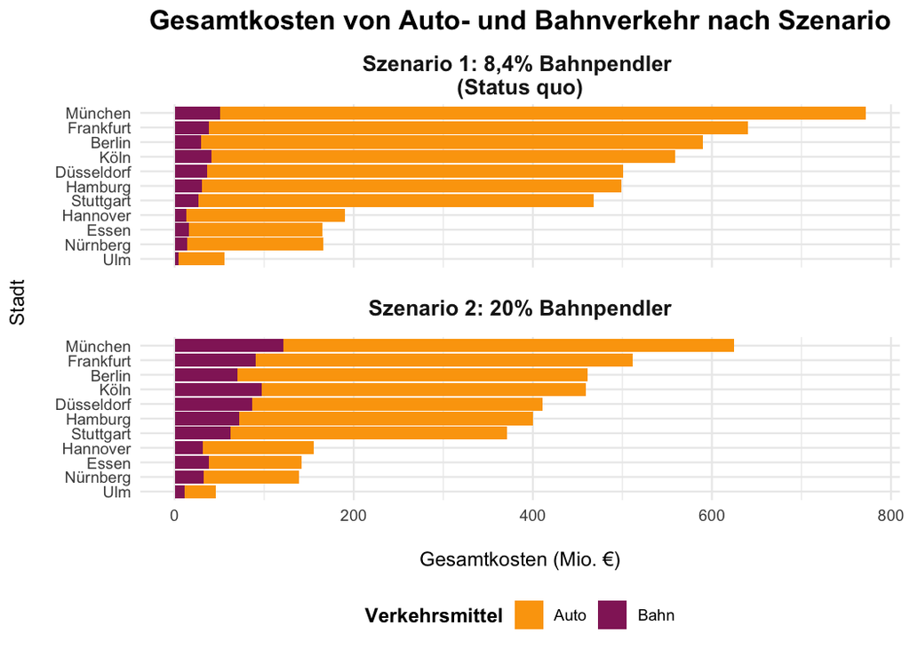

### Beschreibung und Interpretation

**Beschreibung**

Die Abbildung zeigt zwei gestapelte Balkendiagramme, welche die Gesamtkosten des Auto- und Bahnverkehrs für elf deutsche Städte unter zwei unterschiedlichen Szenarien. Das obere Szenario (Szenario 1) geht von einem Bahnpendleranteil von 8,4 Prozent aus, während das untere (Szenario 2) einen erhöhten Anteil von 20 Prozent annimmt. Auf der x-Achse sind die Gesamtkosten in Millionen Euro dargestellt und farblich getrennt nach den Verkehrsmitteln Auto und Bahn ausgewiesen. Für jede Stadt werden die jeweiligen Kosten beider Verkehrsmittel auf der y-Achse gegenübergestellt, sodass Unterschiede zwischen den Szenarien sowie zwischen den Städten sichtbar werden.

**Interpretation**

In beiden Szenarien verursachen die Autofahrten in allen Städten deutlich höhere Gesamtkosten als der Bahnverkehr. Allerdings zeigt sich im Vergleich der beiden Szenarien eine klare Verschiebung der Kostenstruktur. Mit steigendem Bahnpendleranteil im zweiten Szenario sinken die Gesamtkosten des Autoverkehrs in allen betrachteten Städten spürbar, während die Kosten des Bahnverkehrs moderat ansteigen. Insgesamt fallen die kombinierten Gesamtkosten aus Auto- und Bahnverkehr in Szenario 2 jedoch niedriger aus als in Szenario 1. Die Abbildung zeigt, dass ein steigender Bahnpendleranteil nicht nur die Kosten des Bahnverkehrs beeinflusst, sondern auch deutliche Auswirkungen auf den Autoverkehr hat. Wenn mehr Menschen die Bahn nutzen, sinkt dadurch auch die Zahl der Autofahrten. Dies führt zu einer geringeren Verkehrsbelastung auf den Straßen und damit zu weniger Staus. In Folge dessen, reduzieren sich die durch Zeitverluste verursachten Kosten des Autoverkehrs ebenso.

Besonders in großen Städten wie München, Frankfurt oder Berlin ist dieser Effekt ausgeprägt. Dort führt der höhere Anteil an Bahnpendlern zu einer deutlichen Reduktion der autoverkehrsbedingten Kosten, die den Anstieg der Bahnkosten überkompensiert. Am Beispiel München lässt sich dieser Effekt besonders deutlich erkennen: Während im ersten Szenario die Gesamtkosten bei rund 780 Mio. Euro liegen, sinken sie im zweiten Szenario auf etwa 620 Mio. Euro. Dies zeigt, dass ein höherer Bahnpendleranteil allein in dieser Stadt zu einer potenziellen Kosteneinsparung von rund 160 Mio. Euro führen kann. In kleineren Städten wie Ulm oder Nürnberg sind die absoluten Kosteneffekte geringer, die relative Veränderung zwischen den Szenarien folgt jedoch demselben Muster.

Die Abbildung verdeutlicht somit, dass eine Verlagerung vom Auto auf die Bahn Potenzial hat, die volkswirtschaftlichen Gesamtkosten des Verkehrs deutlich zu senken. Insbesondere in Städten mit hohem Verkehrsaufkommen können höhere Bahnanteile zu einer effizienteren und kostengünstigeren Verkehrsstruktur beitragen.

# Politikempfehlung – Ihre Synthese

Sie haben nun umfangreiche Analysen durchgeführt und viele Erkenntnisse über die Bahn gewonnen. Jetzt ist es Zeit, diese zu einer **kohärenten Empfehlung** zusammenzufügen.

**Szenario:** Sie sind Berater:in des Bundesministeriums für Digitales und Verkehr. Die Ministerin bittet Sie um eine evidenzbasierte Politikempfehlung zur Verbesserung des Pendlerverkehrs in Deutschland.

16. Formulieren Sie eine **Politikempfehlung** für das Bundesministerium für Digitales und Verkehr.

Schreiben Sie eine **Executive Summary (max. 5 Sätze)**. Fassen Sie hierbei die wichtigsten Erkenntnisse aus ihrem Projekt zusammen. Was ist die zentrale Botschaft?

Formulieren Sie 3 konkrete Empfehlungen. Jede muss enthalten:

- Ein konkretes **Ziel** (Was soll erreicht werden?)
- Eine messbare **Maßnahme** (Wie wird es umgesetzt?)
- Eine **Begründung mit Zahlen** aus Ihrer Analyse
- Nennen Sie **zwei Limitationen** Ihrer Datengrundlage
- Was würden Sie mit **zusätzlichen Daten** noch untersuchen?

### Executive Summary

Unsere Analyse des Projekts zeigt, dass sich die Pendlerströme in Deutschland stark auf wenige große Metropolen und wirtschaftliche Zentren bündeln, die täglich eine große Zahl an Einpendlern aus dem Umland anziehen und dadurch Verkehrsinfrastruktur und Verkehrssysteme besonders stark belasten. Diese räumliche Konzentration führt zu erheblichen Zeit- und Kostenverlusten, da sowohl der Straßenverkehr durch Staus als auch der Schienenverkehr durch Verspätungen und Ausfälle zunehmend an seine Kapazitätsgrenzen stößt. Ein höherer Bahnanteil im Pendelverkehr kann diese Belastungen wirksam reduzieren, da weniger Autofahrten zu einer geringeren Verkehrsbelastung führen und somit auch die verbleibenden Autofahrer von kürzeren Stauzeiten profitieren. Zentrale Botschaft: Ein zuverlässigerer und attraktiverer Bahnverkehr in Kombination mit einer gezielten Kapazitätsentlastung in Pendlerregionen kann Stau- und Verspätungskosten messbar und kurzfristig senken.

### Handlungsempfehlungen für das Bundesministerium für Digitales und Verkehr

**Priorisierung überlasteter Streckenabschnitte im Schienenverkehr**  
Ziel der Maßnahme ist es, die Zuverlässigkeit des Bahnverkehrs auf besonders stark belasteten Streckenabschnitten deutlich zu verbessern und dadurch Verspätungen zu reduzieren. Hierzu sollte eine streckenbezogene Priorisierung von Investitionen eingeführt werden, bei der insbesondere jene Abschnitte des Schienennetzes ausgebaut oder betrieblich entlastet werden, auf denen sich Verspätungen regelmäßig häufen. Konkret umfasst das Maßnahmen wie den Ausbau zusätzlicher Gleise, die Schaffung von Überholmöglichkeiten sowie die betriebliche Trennung von Fern- und Nahverkehr.

Die Analyse der Bahnhöfe mit den höchsten durchschnittlichen Verspätungen in Aufgabe 8 zeigt, dass sich diese häufig auf wenige Streckenabschnitte konzentrieren. Mehrere der zehn am stärksten verspäteten Bahnhöfe liegen auf derselben Strecke was auf systematische Überlastungen hinweist. Die durchschnittlichen Verspätungen an diesen Bahnhöfen liegen im Bereich von über zwölf Minuten und verdeutlichen das Ausmaß der zeitlichen Verluste für die dortigen Pendler. Vor allem auf den Strecken zwischen Köln und Mainz treten besonders hohe Verspätungen auf. Mit durchschnittlichen Verspätungen von bis zu rund 14 Minuten an Bahnhöfen wie Bad Breisig und Sinzig erscheint ein gezielter Ausbau dieser Strecke daher besonders sinnvoll und wirkungsvoll.

Die Aussagekraft der Analyse ist allerdings begrenzt, da die betrachteten Verspätungen auf Durchschnittswerten beruhen und damit keine Informationen über die Streuung oder über besonders extreme Verzögerungen liefern. Zudem werden Zugausfälle in der Datengrundlage nicht berücksichtigt, obwohl diese für die tatsächliche Belastung der Reisenden eine zentrale Rolle spielen. Mit zusätzlichen Daten ließe sich untersuchen, welche konkreten Ursachen auf den betroffenen Strecken zu den hohen Verspätungen führen. Dazu zählen Informationen zur Gleisbelegung, zu Baustellen, zum Anteil von Güterverkehr sowie zu betrieblichen Vorrangregelungen zwischen Fern- und Nahverkehr. Diese Daten würden es ermöglichen, gezieltere und wirksamere Maßnahmen für einzelne Streckenabschnitte abzuleiten.

**Verbesserung der Preisattraktivität des Bahnverkehrs**  
Ziel dieser Maßnahme ist es, die Nutzung der Bahn im Pendelverkehr durch niedrigere Zugangskosten zu erhöhen und damit eine Verlagerung vom Auto auf die Bahn zu fördern, um den Straßenverkehr zu entlasten und volkswirtschaftliche Gesamtkosten zu senken. Hierzu sollten preisliche Anreize für Pendler ausgebaut werden, etwa durch eine weitere Vergünstigung des Deutschlandtickets oder ergänzende regionale Pendlerabonnements zu reduzierten Preisen.

Eine Einschränkung dieser Empfehlung könnte sein, dass dieses Szenario keine individuellen Verhaltensreaktionen auf Preisänderungen abbildet, sondern von vereinfachten Annahmen zur Verkehrsmittelwahl ausgeht.Mit zusätzlichen Daten, etwa aus Pendlerbefragungen oder Ticketverkaufsstatistiken, ließe sich genauer untersuchen, wie stark Preisänderungen die Verkehrsmittelwahl beeinflussen und welche Einkommensgruppen besonders sensibel auf tarifliche Anreize reagieren.

**Angebotsausbau im Nahverkehr durch dichtere Taktungen und Netzausbau**  
Ziel dieser Maßnahme ist es, die Attraktivität und Zuverlässigkeit des Bahnverkehrs im Pendelverkehr durch kürzere Wartezeiten und stabilere Verbindungen zu erhöhen, um mehr Pendler dauerhaft für die Bahn zu gewinnen. Dazu sollten insbesondere in den Hauptverkehrszeiten dichtere Taktungen im Nahverkehr eingeführt sowie Engpässe im Schienennetz gezielt beseitigt werden. Dies umfasst unter anderem den Ausbau zusätzlicher Gleise, die Erhöhung der Streckenkapazität sowie betriebliche Maßnahmen zur Stabilisierung des Fahrplans.

Das Liniendiagramm aus Aufgabe 6 zeigt, dass die höchste Nachfrage im Bahnverkehr während der morgendlichen und abendlichen Hauptpendelzeiten auftritt, mit Spitzenwerten von bis zu rund 17 Tsd. Fahrten pro Stunde. Gerade in diesen Zeitfenstern sind Verspätungen besonders häufig, da das Schienennetz stark ausgelastet ist und bereits kleine Störungen zu Dominoeffekten führen können (Aufgabe 7). Wie aus Aufgabe 5 hervorgeht, entfällt der Großteil der Zugfahrten auf den Regional- und S-Bahn-Verkehr, der damit den zentralen Verkehrsträger für Pendler darstellt. Verbesserungen des Angebots in diesem Bereich erreichen daher besonders viele Fahrgäste und können den zeitlichen Schaden durch Verspätungen deutlich reduzieren. Ein verlässliches und eng getaktetes Bahnangebot, insbesondere im Nahverkehr zu den Hauptpendelzeiten, ist daher eine zentrale Voraussetzung für eine nachhaltige Verkehrsverlagerung.

Bei dieser Anaylse ist es schwer eine genaue Trennung zwischen infrastrukturellen und betrieblichen Ursachen von Verspätungen, sodass die Wirkung einzelner Maßnahmen nicht isoliert bewertet werden kann. Mit detaillierten Daten zur Auslastung einzelner Linien, zur Kapazitätsnutzung des Schienennetzes sowie zu infrastrukturellen Engpässen ließe sich gezielter analysieren, auf welchen Strecken kürzere Taktungen und Netzausbauten den größten Effekt entfalten.

# Zusatzaufgaben (optional)

Bisher haben Sie zwei Dimensionen betrachtet: **Zeit** (Bahn ist schneller) und **Geld** (Verspätungen kosten). Aber es gibt einen dritten, oft vergessenen Aspekt: die **Umwelt**.

Das Auto ist nicht nur langsamer und teurer; es ist auch ein Klimakiller. Ein durchschnittlicher PKW emittiert z.B. etwa **150 g CO2 pro Personenkilometer**.

17. Recherchieren Sie die CO2-Emissionsfaktoren und das Mobilitätsverhalten:
- Erstellen Sie eine kleine Tabelle in der Sie die CO2-Emissionen (in g/Personenkilometer) für folgende Verkehrsmittel auflisten:
  - PKW (Durchschnitt)
  - PKW (Elektro, deutscher Strommix)
  - ICE/IC (Fernverkehr)
  - RE/RB (Nahverkehr)
  - S-Bahn
- Berechnen Sie einen **gewichteten Durchschnitt** für die Bahn, wenn 70% der Pendler Nahverkehr und 30% Fernverkehr nutzen.
- Um wie viel Prozent sind die Bahn-Emissionen niedriger als beim Auto?

*Hinweis:* Nutzen Sie Daten vom Umweltbundesamt oder dem DB Umweltbericht.

CO₂-Emissionen nach Verkehrsmittel

laut Umweltbundesamt

| Verkehrsmittel | g/Personenkilometer |
| --- | --- |
| PKW (Durchschnitt) | 164 |
| PKW (Elektro, Strommix) | 70 |
| ICE/IC (Fernverkehr) | 30 |
| RE/RB (Nahverkehr) | 44 |
| S-Bahn | 42 |

**Beschreibung**

In der vorliegenden Tabelle sind die spezifischen CO₂-Emissionen verschiedener Verkehrsmittel aufgeführt. Berücksichtigt werden dabei Pkw im Durchschnitt, Elektro-Pkw, Fernverkehrszüge (ICE/IC), Regionalzüge (RE/RB) sowie die S-Bahn. Alle Angaben erfolgen in Gramm CO₂ pro Personenkilometer. Ein Personenkilometer beschreibt dabei die Beförderung einer Person über eine Strecke von einem Kilometer und dient als standardisierte Bezugsgröße zum Vergleich der Emissionsintensität unterschiedlicher Verkehrsmittel.

Bei einem angenommenen Nutzungsanteil von 70 % im Schienen-Nahverkehr und 30 % im Schienen-Fernverkehr ergibt sich für die Bahn ein gewichteter Durchschnitt von 39,8 g CO₂ pro Personenkilometer.[^4] Zum Vergleich verursacht ein durchschnittlicher Pkw Emissionen in Höhe von 164 g CO₂ pro Personenkilometer. Damit liegen die spezifischen Emissionen des Schienenverkehrs um rund 76 % unter denen des Pkw.[^5]

Dieser deutliche Unterschied verdeutlicht das hohe ökologische Potenzial des Schienenverkehrs im Personenverkehr. Insbesondere im Pendlerverkehr, der durch regelmäßige und hohe Verkehrsaufkommen gekennzeichnet ist, kann eine Verlagerung vom Pkw auf die Bahn einen erheblichen Beitrag zur Reduktion verkehrsbedingter CO₂-Emissionen leisten.

Die Emissionsfaktoren stammen vom Umweltbundesamt.[^6]

[Umweltbundesamt – Emissionen im Verkehr](https://www.umweltbundesamt.de/system/files/medien/366/bilder/dateien/vtv_2024_pv_tab_pdf.pdf)

18. Die Studie **“Mobilität in Deutschland” (MiD 2023)** ist die wichtigste Datenquelle zum Mobilitätsverhalten in Deutschland. Sie ermöglicht einen Vergleich mit 2017 (vor Corona).

Lesen Sie den [MiD 2023 Kurzbericht](https://www.mobilitaet-in-deutschland.de/pdf/MiD2023_Kurzbericht.pdf) und beantworten Sie:

- **Modal Split:** Wie hat sich der Anteil des öffentlichen Verkehrs (ÖV) am Gesamtverkehr zwischen 2017 und 2023 verändert?
- **Homeoffice-Effekt:** Wie hat sich die durchschnittliche Tagesstrecke verändert? Was ist laut MiD der Hauptgrund für diese Veränderung?
- **Stadt vs. Land:** Welchen Anteil hat das Deutschlandticket in Metropolen vs. ländlichen Räumen? Was bedeutet das für die Ulm-Region?
- **Implikation für CO2:** Welche Schlussfolgerung ziehen Sie aus diesen Veränderungen für das CO2-Einsparpotenzial durch Bahnpendeln? (2-3 Sätze)

### Mobilität in Deutschland (MiD 2023)

**Modal Split:**

Die MiD 2023 zeigt für den öffentlichen Verkehr, dass dieser mit etwas weniger Fernkilometern und geringfügigem Minus im Nahverkehr unter dem Strich etwa stabil bleibt und sich weiterhin langsam aus dem Corona-Tief erholt. Einschließlich des Fernverkehrs erreicht der ÖV 2023 einen Anteil von 11 Prozent des Verkehrsaufkommens, im Vergleich zu 10 Prozent im Jahr 2017[^7]. Das Jahr 2017 ist repräsentativ für die Werte in der Zeit vor Corona. Zwischen 2017 und 2023 gab es zeitweise einen starken Rückgang der Zahlen, was offensichtlich mit dem Lockdown zusammenhängt, in welchem der Verkehr drastisch eingeschränkt wurde und daher kein realistischer Vergleich mit Werten aus dieser Zeit gemacht werden kann, wenn es um Veränderungen im öffentlichen Verkehr geht. Auch kurz nach nach dem Corona-Lockdown, war der Verkehr nicht wieder direkt auf dem Stand von 2017, sondern es dauerte, bis Corona-bedingte Maßnahmen, die vor allem den öffentlichen Verkehr einschränkten, vollends aufgehoben wurden. Deshalb wird der Vergleich zwischen 2017 und 2023 herangezogen. Anschaulich wird dabei, dass der öffentliche Verkehr an Anteil am Verkehrsaufkommen gewinnt, jedoch durch das Corona-Tief kein besonders großes Wachstum verschreibt.

**Homeoffice-Effekt:**

Die durchschnittliche Tagesstrecke im Jahr 2023 ist verglichen mit 2017 rückläufig. 2017 liegt sie noch bei 39 Kilometern und 2023 nur noch bei 35. Laut MiD ist dies nicht primär auf eine Verlagerung der Verkehrsmittel zurückzuführen, sondern vor allem auf strukturelle Veränderungen im Arbeitsalltag. Der zentrale Treiber ist der dauerhafte Anstieg von Homeoffice- und Online-Shopping-Möglichkeiten. Viele Erwerbstätige legen an einzelnen Tagen gar keine Arbeitswege mehr zurück oder pendeln seltener. Verglichen mit 2017 wird 2023 auch deutlich häufiger Online-Shopping betrieben, wodurch vor allem in ländlichen Regionen (ca. 17%, die an 1-3 Tagen pro Woche im kleinstädtischen, dörflichen Raum in 2023 online shoppen, verglichen mit ca. 8% in 2017) Fahrstrecken in städtische Räume mit Einkaufszentren wegfallen. Dadurch sinkt die durchschnittliche Tageskilometerleistung, selbst wenn an den Pendeltagen weiterhin ähnlich lange Strecken zurückgelegt werden wie vor Corona. Die MiD spricht hier explizit von einem Nachfragerückgang durch Wegfall von Wegen, nicht von effizienteren Wegen.

**Stadt vs. Land:**

Das Deutschlandticket, welches im Jahr 2023 eingeführt wurde, wird von 16 Prozent der Bevölkerung im Alter ab 14 Jahren genutzt. Die Studie zeigt jedoch eine starke räumliche Differenzierung bei der Nutzung des Deutschlandtickets. In Metropolen und großen Städten ist der Anteil der Deutschlandticket-Nutzenden deutlich höher als in ländlichen Räumen. Der Grund liegt im deutlich besseren ÖV-Angebot: hohe Taktfrequenzen, dichte Netze und gute Erreichbarkeit machen das Ticket dort besonders attraktiv. In ländlichen Regionen ist der Nutzen des Deutschlandtickets begrenzt, da Angebot, Zuverlässigkeit und Reisezeiten des ÖV oft nicht konkurrenzfähig zum Auto sind. Dafür spricht eine Befragung über die “ZUFRIEDENHEIT MIT DER VERKEHRSSITUATION AM WOHNORT”, welche Teil der MiD-Studie ist. Sie zeigt, dass vor allem in ländlichen Regionen im kleinstädtischen, dörflichen Raum (34% empfinden ÖPNV als mangelhaft/ ungenügend), als auch in der Mittelstadt, im dörflichen Raum (50% empfinden ÖPNV als mangelhaft/ ungenügend) große Unzufriedenheit über die ÖPNV herrscht. Für die Region Ulm bedeutet dies eine Zwischenstellung: Als Regiopole und Großstadt mit guter Schienenanbindung profitiert die Stadt Ulm stärker als ländliche Räume, aber weniger als große Metropolen wie München oder Berlin, vor allem, da viele Dörfer und Stadtteile Ulms im Umkreis liegen. Die schon genannte Studie, würde eine Stadt von Ulms Größe so einschätzen, dass es eine mehr oder weniger ausgewogene Meinungsvielfalt gibt. Etwa 44% befinden die ÖPNV als gut bis sehr gut und der Rest als befriedigend bis mangelhaft. Dadurch, dass viele Dörfer in der Umgebung liegen, ist die Stadt somit auch von der dort herrschenden, negativen Verkehrssituation betroffen. Vor allem dadurch, dass viele Menschen in die Schule, zur Arbeit oder an die Universität pendeln.

**Implikation für CO2:**

Aus den MiD-Ergebnissen lässt sich ableiten, dass das CO₂-Einsparpotenzial durch Bahnpendeln real, aber begrenzt ist. Zwar steigt der ÖV-Anteil leicht und das Deutschlandticket senkt Nutzungshürden, gleichzeitig reduziert Homeoffice die Zahl der Pendelwege insgesamt. Große zusätzliche CO₂-Effekte entstehen daher vor allem dort, wo Autopendler dauerhaft auf die Bahn umsteigen und das Angebot zuverlässig und zeiteffizient ist.

19. Berechnen Sie die **CO2-Ersparnis** für die 11 analysierten Städte.

**Datensatz:** `co2_analyse` (aus Aufgabe 4) – enthält Streckenlängen, Einpendlerzahlen und vorberechnete Werte

**Annahmen:**

- 220 Arbeitstage pro Jahr
- 2 Fahrten pro Tag (Hin + Zurück)
- CO2-Auto: 150 g/km, CO2-Bahn: 47 g/km (gewichteter Durchschnitt)

Berechnen Sie für **jeden Umsteiger** (Auto $\rightarrow$ Bahn):

- Jährliche Kilometer
- CO2-Emissionen mit Auto (kg/Jahr)
- CO2-Emissionen mit Bahn (kg/Jahr)
- **Ersparnis** (kg/Jahr)

Nun sollten Sie eine Szenario Analyse ähnlich wie in Aufgabe 15 durchführen: Wenn sich der Bahnanteil von 8,4% auf 20% erhöht: wie viele Tonnen CO2 würden in den 11 Städten jährlich eingespart?

Visualisieren Sie die CO2-Ersparnis pro Stadt.

Stellen Sie die Ersparnis in Kontext, um die Ersparnis greifbarer zu machen, z.B. wie viele **Mallorca-Flüge** (hin + zurück, ~750 kg CO2) entspricht das?

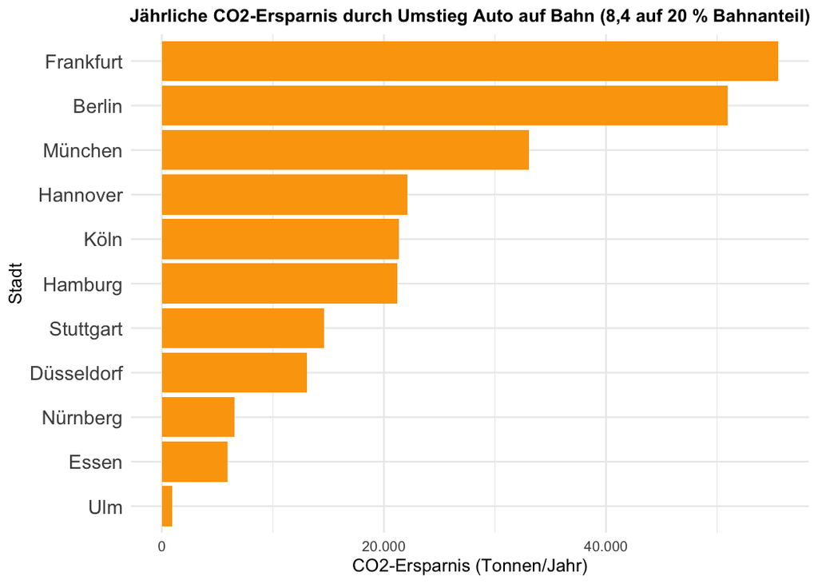

### CO2-Einsparung

**Einordnung: Vergleich mit Mallorca-Flügen**

Zur besseren Einordnung der Größenordnung lässt sich die CO₂-Ersparnis mit Flugreisen vergleichen. Ein Hin- und Rückflug nach Mallorca verursacht etwa 750 Kg CO₂ pro Person. Die gesamte jährliche CO₂-Ersparnis ergibt sich durch die Aggregation der städtischen Einsparpotenziale. Hierfür werden die zusätzlichen CO₂-Einsparungen aller elf Städte aufsummiert. Die jährliche Einsparung von 245.307 Tonnen C0₂, entspricht damit genau 327.076 Hin- und Rückflügen (245.307.000 Kg/ 750 Kg).

Die Ergebnisse zeigen, dass bereits eine moderate Erhöhung des Bahnanteils im Pendelverkehr ein sehr hohes CO₂-Einsparpotenzial besitzt. Im Vergleich zu individuellen Klimaschutzmaßnahmen handelt es sich um einen strukturellen Hebel mit großer Wirkung. Insbesondere in stark pendelgeprägten Metropolregionen, wie Frankfurt, Berlin oder München, in denen eine Erhöhung des Bahnanteils auf 20%, jeweils eine CO₂-Ersparnis von über 30.000 Tonnen im Jahr bewirken würde, kann eine Verlagerung vom Auto auf die Bahn einen substantiellen Beitrag zur Emissionsreduktion im Verkehrssektor leisten.

# Anhang

## Anhang A: Beschreibung der bereitgestellten Datensätze

### 1. Bahnhof-Kreis-Mapping (`bahnhof_ags_mapping.csv`)

Dieses Mapping ist essenziell für die Verknüpfung von Bahn- und Pendlerdaten. Die Bahndaten sind auf **Bahnhofsebene** (z.B. “München Hbf”), die Pendlerdaten auf **Kreisebene** (z.B. “München, Landeshauptstadt”). Der AGS (Amtlicher Gemeindeschlüssel) ist der Schlüssel, der beide Welten verbindet.

**Wichtige Variablen:**

- `station_name`: Name des Bahnhofs
- `ags`: Amtlicher Gemeindeschlüssel (5-stellig für Kreise)
- `kreis_name`: Name des Landkreises/der kreisfreien Stadt

### 2. Fahrtzeit-Vergleich OSRM (`fahrtzeit_osrm_vergleich.csv`)

Für einen fairen Vergleich Auto vs. Bahn brauchen wir **realistische Fahrtzeiten**. OSRM (Open Source Routing Machine) berechnet echte Straßenrouten basierend auf OpenStreetMap – keine Luftlinien, sondern tatsächliche Straßenverbindungen mit Abbiegevorgängen, Geschwindigkeitsbegrenzungen und Straßentypen.

**Wichtige Variablen:**

- `stadt`: Zielstadt der Pendlerstrecke
- `strecke_name`: Beschreibung der Route (z.B. “Dachau $\rightarrow$ München”)
- `auto_distanz_km`: Fahrstrecke mit dem Auto in km
- `auto_hvz_min`: Fahrzeit Auto in der Hauptverkehrszeit (mit Staufaktor)
- `bahn_planzeit_min`: Fahrzeit laut Fahrplan
- `bahn_verspaetung_min`: Durchschnittliche Verspätung
- `bahn_real_min`: Realistische Bahnfahrzeit (Fahrplan + Verspätung)

**Wie wurde das Routing durchgeführt?**

1. **Koordinaten ermitteln:** Für jede Pendlerstrecke wurden Start- und Zielkoordinaten definiert (z.B. Stadtzentrum Dachau $\rightarrow$ München Hauptbahnhof).
2. **OSRM-API abfragen:** Über die öffentliche OSRM-Demo-API (`router.project-osrm.org`) wurden für jede Route Distanz und Fahrzeit abgefragt. Die API gibt die schnellste Route zurück, basierend auf dem aktuellen Straßennetz.
3. **Staufaktor anwenden:** Die OSRM-Basisfahrzeit entspricht einer Fahrt bei freiem Verkehr. Für die Hauptverkehrszeit (HVZ) wurde ein Staufaktor von 1,3-1,5 angewendet, basierend auf den INRIX-Daten der jeweiligen Stadt.
4. **Bahn-Daten ergänzen:** Die Bahnfahrzeiten stammen aus dem DB-Fahrplan, ergänzt um die durchschnittliche Verspätung aus unserer Analyse.

**Weiterführende Links:**

- [OSRM Projekt-Website](http://project-osrm.org/) – Dokumentation und Demo
- [OSRM API-Dokumentation](http://project-osrm.org/docs/v5.24.0/api/) – Technische Details zur API
- [OpenStreetMap](https://www.openstreetmap.org/) – Die Kartendaten, auf denen OSRM basiert
- R-Paket [`osrm`](https://cran.r-project.org/package=osrm) – Für eigene OSRM-Abfragen in R

### 3. Ulm-Pendlerrouten (`ulm_pendlerrouten.csv`)

Da Sie in Ulm studieren, analysieren wir die wichtigsten Pendlerrouten in die Stadt genauer. Dieser Datensatz enthält die 5 wichtigsten Einpendler-Gemeinden mit detaillierten Informationen zur Erreichbarkeit.

**Wichtige Variablen:**

- `start_ort`: Startgemeinde der Pendlerroute
- `ziel_ort`: Zielort (Ulm)
- `auto_dauer_min`: Fahrzeit mit dem Auto
- `auto_hvz_min`: Fahrzeit Auto in der Hauptverkehrszeit
- `bahn_fahrplan_min`: Bahnfahrzeit laut Fahrplan
- `bahn_real_min`: Realistische Bahnfahrzeit
- `hat_bahnhof`: TRUE/FALSE – hat der Startort einen Bahnanschluss?
- `pendler_geschaetzt`: Geschätzte Anzahl Pendler auf dieser Route

### 4. Entgeltstatistik (`ba_entgeltstatistik_2024.csv`)

Um die volkswirtschaftlichen Kosten von Verspätungen zu berechnen, brauchen wir **regionale Lohndaten**. Diese haben wir von der Bundesagentur für Arbeit heruntergeladen.

**Wichtige Variablen:**

- `kreis_name`: Name des Kreises/der Stadt
- `ags`: Amtlicher Gemeindeschlüssel
- `medianentgelt_brutto_monat`: Median-Bruttomonatsentgelt in Euro

**Quelle:** Bundesagentur für Arbeit, Entgeltstatistik 2024

Bundesministerium für Verkehr und digitale Infrastruktur. „Mobilität in Deutschland 2017“. Bundesministerium für Verkehr und digitale Infrastruktur, n.d. https://www.mobilitaet-in-deutschland.de/archive/pdf/MiD2017_ZusammenfassungKurzreport.pdf.

Deutsche Bahn AG. „Generalsanierung in Nordrhein-Westfalen: Köln–Bonn–Koblenz“. Deutsche Bahn, 2026. https://generalsanierung-nrw.deutschebahn.com/korridore/koeln-bonn-koblenz.html.

Deutsche Bahn AG, Axel Hartmann. „Erläuterung Pünktlichkeitswerte für den Dezember 2025“. Deutsche Bahn, 2025. https://www.deutschebahn.com/de/konzern/konzernprofil/zahlen_fakten/puenktlichkeitswerte-6878476.

[^1]: Deutsche Bahn AG, Axel Hartmann, „Erläuterung Pünktlichkeitswerte für den Dezember 2025“, Deutsche Bahn, 2025, https://www.deutschebahn.com/de/konzern/konzernprofil/zahlen_fakten/puenktlichkeitswerte-6878476.
[^2]: Deutsche Bahn AG, Axel Hartmann
[^3]: Deutsche Bahn AG, „Generalsanierung in Nordrhein-Westfalen: Köln–Bonn–Koblenz“, Deutsche Bahn, 2026, https://generalsanierung-nrw.deutschebahn.com/korridore/koeln-bonn-koblenz.html.
[^4]: Berechnung: 0,7*44+0.3*30 = 39.8
[^5]: Berechnung: (1−39,8/164)⋅100≈75,7%
[^6]: Umweltbundesamt (2023): Vergleich der Emissionen im Personenverkehr.
[^7]: Bundesministerium für Verkehr und digitale Infrastruktur, „Mobilität in Deutschland 2017“, Bundesministerium für Verkehr und digitale Infrastruktur, n.d., https://www.mobilitaet-in-deutschland.de/archive/pdf/MiD2017_ZusammenfassungKurzreport.pdf.